# Variation in the production of te reo Māori opening vowel sequences: Supplementary Materials

Authors

Affiliations

Kirsten Culhane

New Zealand Institute of Language, Brain and Behaviour, University of Canterbury

Jen Hay

New Zealand Institute of Language, Brain and Behaviour, University of Canterbury

Department of Linguistics, University of Canterbury

Simon Todd

University of California, Santa Barbara

Márton Sóskuthy

University of British Columbia

Allie Osborne

Department of Linguistics, University of Canterbury

Penny Harris

Department of Linguistics, University of Canterbury

Kate Maindonald

Department of Linguistics, University of Canterbury

Jeanette King

Aotahi School of Māori and Indigenous Studies, University of Canterbury

New Zealand Institute of Language, Brain and Behaviour, University of Canterbury

Forrest Panther

Department of Linguistics, University of Canterbury

Peter Keegan

University of Auckland

Published

February 2, 2026

# 1 Overview

This markdown file contains supplementary materials for the manuscript “Variation in the production of te reo Māori opening vowel sequences”. It contains all code used for data selection, acoustic measurements and filtering, as well as the analysis and data visualisations. This document is structured as follows:

- Section 2 loads the R packages used
- Section 3 outlines the data selection and annotation procedure
- Section 4 contains the code for measuring formats, pitch, intensity, and for for filtering the data laid out in §3.3 of the manuscript. This section contains a number of non-executable chunks, some of which require a LaBB-CAT account to run. They have been included for archiving purposes.
- Section 5 explores how many data points are lost by our filtering process, which is reported in Footnote 3, 4 and 5.
- Section 6 contains the code for the fPCA analysis. which is described in §3.4 of the manuscript and relevant results reported in Appendix A
- Section 7 contains the code for filtering the duration data, which is described in §3.3.3 of the manuscript
- Section 8 contains the code for the uPCA analysis and visualizations, which are presented in §4.1 of the manuscript
- Section 9 examines the possibility that speakers with predominantly high uPC1 scores and predominantly low uPC1 scores have different monophthong spaces, and that the different trajectory we see between high and low uPC1 tokens are actually a reflection of these differences (Footnote 7 of the manuscript)
- Section 10 contains the code for the regression analysis and visualizations, which are presented in §4.2 of the manuscript
- Section 11 contains the code for the speaker intercept analysis, which is described in §4.3.1 of the manuscript
- Section 12 contains code for the visualizations of monophthongs and sequence trajectories, plotted per speaker category, which are presented in §4.3.2 of the manuscript
- Section 13 examines the possibility that there a relationship between raising of /e/ and merging of /ia/ and /ea/ in Māori, which is disscussed in §4.3.2 of the manuscript

# 2 Libraries

1. Required libraries.

**Click here to view code.**

```r
# Data manipulation and visualisation
library(tidyverse)
library(janitor)
library(formatR)
library(gganimate)
library(gridExtra)
library(grid)
library(ggrepel)
library(scales)
library(glue)
library(factoextra)
library(gridExtra)
library(geomtextpath)
library(sjPlot)
library(RColorBrewer)

#Measurements
library(nzilbb.labbcat)
library(rmdformats)
library(rPraat)

# Statistical analyses
library(nzilbb.vowels)
library(fdapace)
library(mgcv)
library(locfit)
library(itsadug)
library(qgam)
library(lme4)
library(lmerTest)
library(car)
library(emmeans)

# Other
library(here) # localised file paths
library(knitr)
library(kableExtra) # html tables when rendering
library(grateful) # write package citations at end of document
library(extrafont) # to use custom fonts in
library(xtable)
```

# 3 Data selection and annotation (Manuscript §3.2)

1. Data from the MAONZE corpus: all tokens of opening sequences, and monopthongs which occur between two consonants

**Click here to view code.**

```r
opening_seqs <- read.csv(here("Data", "MAONZE_opening_seqs.csv"))

betweenConsonantsMatches <- read.csv(here("Data", "betweenConsonantsMatches.csv"))


participant_info <- opening_seqs %>%
  select(Speaker, participant_gender, category) %>%
  unique()
```

2. Various functions for data selection

Function to remove punctuation and whitespace

**Click here to view code.**

```r
remove_punctuation_whitespace <- function(string) {
  # Use gsub to replace punctuation and whitespace with an empty string
  gsub("[[:punct:][:space:]]", "", string)
}
```

Functions to identify if vowel sequence is initial or final in the word

**Click here to view code.**

```r
VV_initial <- function(word, vowel_sequence) {
  return(substr(word, 1, nchar(vowel_sequence)) == vowel_sequence)
}

VV_final <- function(word, vowel_sequence) {
  return(substr(word, nchar(word) - nchar(vowel_sequence) + 1, nchar(word)) == vowel_sequence)
}
```

Function to identify if words are V-final or V-initial

**Click here to view code.**

```r
V_final <- function(string) {
  string <- tolower(string)
  n <- nchar(string)
  if (n < 1) {
    return(FALSE)
  }
  last_char <- substring(string, n, n)
  last_char %in% c("a", "e", "i", "o", "u")
}

V_initial <- function(string) {
  first_char <- tolower(substring(string, 1, 1))
  first_char %in% c("a", "e", "i", "o", "u")
}
```

Function to identify sequences of three vowels

**Click here to view code.**

```r
three_vowels <- function(word, vowel_sequence) {
  pattern <- paste0("(?<=[aeiou])", vowel_sequence, "|", vowel_sequence, "(?=[aeiou])")
  return(grepl(pattern, word, perl = TRUE))
}
```

3. Prepare Before.Match (previous word) data. Here we replace V: with vv in the Before.Match column. This is because colons <:> will affect the results when filtering instances where the previous word is vowel final (i.e. if a word ends with orthographic v:, it will not be considered vowel-final )

**Click here to view code.**

```r
opening_seqs$Before.Match = str_replace_all(opening_seqs$Before.Match, "a:", "aa")
opening_seqs$Before.Match = str_replace_all(opening_seqs$Before.Match, "e:", "ee")
opening_seqs$Before.Match = str_replace_all(opening_seqs$Before.Match, "i:", "ii")
opening_seqs$Before.Match = str_replace_all(opening_seqs$Before.Match, "o:", "oo")
opening_seqs$Before.Match = str_replace_all(opening_seqs$Before.Match, "u:", "uu")
```

4. Exclude various vowel sequences using functions defined above

**Click here to view code.**

```r
data_filtered <- opening_seqs %>%
#determine if the sequence is initial in the word
   mutate(word_VV_initial = mapply(VV_initial,
                                        Target.orthography,
                                        Target.vowelCluster)) %>%
   #remove punctuation from before matches, bcs  can affect the results of  prev_V (e.g various words end with . , which could mean  it is not  considered vowel-final )
  mutate(Before.Match = remove_punctuation_whitespace(Before.Match)) %>%
  #determine if the previous word is V final
   mutate(prev_v = ifelse(sapply(Before.Match, V_final), TRUE, FALSE)) %>%
  #if word_VV_initial = TRUE and prev_v = TRUE, filter it out
    filter(!(word_VV_initial & prev_v)) %>%
#determine if the sequence is final in the word
   mutate(word_VV_final = mapply(VV_final,
                                        Target.orthography,
                                        Target.vowelCluster)) %>%
   #is the next word vowel initial?
  mutate(following_V = ifelse(sapply(After.Match, V_initial), TRUE, FALSE)) %>%
  #if word_VV_final = TRUE and following_V = TRUE, filter it out
  filter(!(word_VV_final & following_V ))  %>%
  #determine if sequence occurs in seq of 3 vowels
mutate(three_vowels = mapply(three_vowels, Target.orthography, Target.vowelCluster)) %>%
  #filter out three_vowels = TRUE
 filter(!(three_vowels)) %>%
#filter out instances where seq occurs more than once
    mutate(VV_occurence = str_count(Target.orthography, Target.vowelCluster)) %>%
  filter(VV_occurence < 2)  %>%
#filter out instances where the sequence is preceded by a long vowel
  filter(!mapply(function(vowel, word) grepl(paste0(":", vowel), word),
                 Target.vowelCluster, Target.orthography))

#remove unnecessary columns
data_filtered <- data_filtered %>%
  select(-word_VV_final, -following_V, -word_VV_initial, -prev_v, -VV_occurence, -three_vowels)
```

5. Save as the selected data as a .csv

**Click here to view code.**

```r
write.csv(data_filtered, here("Data", "opening_seqs_selected_data.csv"))
```

# 4 Acoustic measurements and filtering

## 4.1 Formants (Manuscript §3.3.1)

The following code extracts praat measurements for the formants, and requires a LaBB-CAT account. Chunks are set not to evaluate, measurements can be read in from provided csvs below.

### 4.1.1 Sequences formant measurments

1. Define URL + intervals, separate data by sequence

**Click here to view code.**

```r
url <- "https://labbcat.canterbury.ac.nz/maonze/"
intervals <- c(.1,.2,.3,.4, .5, .6, .7, .8, .9)

ia = data_filtered %>% filter(Target.vowelCluster == "ia")
ua = data_filtered %>% filter(Target.vowelCluster == "ua")
oa = data_filtered %>% filter(Target.vowelCluster == "oa")
ea = data_filtered %>% filter(Target.vowelCluster == "ea")
```

2. /ia/ formant measurements

**Click here to view code.**

```r
iaformants <-
ia  %>%
    mutate(nzilbb.labbcat::processWithPraat(
    url,
    MatchId,
    Target.vowelCluster.start,
    Target.vowelCluster.end,
    window.offset=0.025,
    paste(
      praatScriptFormants(sample.points = intervals,
                              formants = c(1, 2)))))


write.csv(iaformants, here("Data", "iaFormantsRaw.csv"))
```

3. /ea/ formant measurements

**Click here to view code.**

```r
eaformants <- ea  %>%
    mutate(nzilbb.labbcat::processWithPraat(
    url,
    MatchId,
    Target.vowelCluster.start,
    Target.vowelCluster.end,
    window.offset=0.025,
    paste(
      praatScriptFormants(sample.points = intervals,
                              formants = c(1, 2)))))

write.csv(eaformants, here("Data", "eaFormantsRaw.csv"))
```

4. /oa/ formant measurements

**Click here to view code.**

```r
oaformants <-
oa  %>%
    mutate(nzilbb.labbcat::processWithPraat(
    url,
    MatchId,
    Target.vowelCluster.start,
    Target.vowelCluster.end,
    window.offset=0.025,
    paste(
      praatScriptFormants(sample.points = intervals,
                              formants = c(1, 2)))))

write.csv(oaformants, here("Data", "oaFormantsRaw.csv"))
```

5. /ua/ formant measurements

**Click here to view code.**

```r
uaformants <-
ua  %>%
    mutate(nzilbb.labbcat::processWithPraat(
    url,
    MatchId,
    Target.vowelCluster.start,
    Target.vowelCluster.end,
    window.offset=0.025,
    paste(
      praatScriptFormants(sample.points = intervals,
                              formants = c(1, 2)))))

write.csv(uaformants, here("Data","uaFormantsRaw.csv"))
```

6. Read in data if need be

**Click here to view code.**

```r
eaformants <- read.csv(here("Data", "eaFormantsRaw.csv"))
iaformants <- read.csv(here("Data", "iaFormantsRaw.csv"))
oaformants <- read.csv(here("Data", "oaFormantsRaw.csv"))
uaformants <- read.csv(here("Data", "uaFormantsRaw.csv"))
```

7. Combine into a single data frame

**Click here to view code.**

```r
allseqformants = rbind(eaformants,iaformants,oaformants,uaformants)
```

8. Make separate data frames for F1 and F2, pivot longer

**Click here to view code.**

```r
  allf1 =  allseqformants %>% pivot_longer(c(f1_time_0_1,f1_time_0_2,f1_time_0_3,
                 f1_time_0_4,f1_time_0_5,f1_time_0_6,
                 f1_time_0_7,f1_time_0_8,f1_time_0_9),
               names_to = "f1time",
               values_to = "f1")
  allf2 =  allseqformants %>% pivot_longer(c(f2_time_0_1,f2_time_0_2,f2_time_0_3,
                 f2_time_0_4,f2_time_0_5,f2_time_0_6,
                 f2_time_0_7,f2_time_0_8,f2_time_0_9),
               names_to = "f2time",
               values_to = "f2")

 alllong = allf1
 alllong$temptime = allf1$f1time
 alllong$time = as.numeric(substr(alllong$temptime, 11,11))
 alllong$f1 = allf1$f1
 alllong$f2 = allf2$f2
```

9. Remove NAs

**Click here to view code.**

```r
alllong = alllong[is.na(alllong$f1) != TRUE,]
alllong = alllong[is.na(alllong$f2) != TRUE,]
alllong$f1 = as.numeric(alllong$f1)
alllong$f2 = as.numeric(alllong$f2)
alllong$time = as.numeric(alllong$time)
```

10. Save data frame

**Click here to view code.**

```r
write.csv(alllong, here("Data", "openningseqs_formants_all_long.csv"))
```

We will return later to normalize the data.

### 4.1.2 Monophthong formant measurements

The following chunks extract midpoint values for each monophthong

1. /i/

**Click here to view code.**

```r
monoi = betweenConsonantsMatches %>% filter(Target.teAkaSegment == "i")

monoiformants <-
monoi  %>%
    mutate(nzilbb.labbcat::processWithPraat(
    url,
    MatchId,
    Target.teAkaSegment.start,
    Target.teAkaSegment.end,
    window.offset=0.025,
    paste(
      praatScriptFormants(sample.points = 0.5,
                              formants = c(1, 2)))))

write.csv(monoiformants, here("Data","monoiFormantsRaw.csv"))
```

2. /e/

**Click here to view code.**

```r
monoe = betweenConsonantsMatches %>% filter(Target.teAkaSegment == "e")

monoeformants <-
monoe  %>%
    mutate(nzilbb.labbcat::processWithPraat(
    url,
    MatchId,
    Target.teAkaSegment.start,
    Target.teAkaSegment.end,
    window.offset=0.025,
    paste(
      praatScriptFormants(sample.points = 0.5,
                              formants = c(1, 2)))))

write.csv(monoeformants, here("Data","monoeFormantsRaw.csv"))
```

3. /a/

**Click here to view code.**

```r
monoa = betweenConsonantsMatches %>% filter(Target.teAkaSegment == "a")
monoaformants <-
monoa  %>%
    mutate(nzilbb.labbcat::processWithPraat(
    url,
    MatchId,
    Target.teAkaSegment.start,
    Target.teAkaSegment.end,
    window.offset=0.025,
    paste(
      praatScriptFormants(sample.points = 0.5,
                              formants = c(1, 2)))))

write.csv(monoaformants, here("Data","monoaFormantsRaw.csv"))
```

4. /o/

**Click here to view code.**

```r
monoo = betweenConsonantsMatches %>% filter(Target.teAkaSegment == "o")

monooformants <-
monoo  %>%
    mutate(nzilbb.labbcat::processWithPraat(
    url,
    MatchId,
    Target.teAkaSegment.start,
    Target.teAkaSegment.end,
    window.offset=0.025,
    paste(
      praatScriptFormants(sample.points = 0.5,
                              formants = c(1, 2)))))

write.csv(monooformants, here("Data","monooFormantsRaw.csv"))
```

5. /u/

**Click here to view code.**

```r
monou = betweenConsonantsMatches %>% filter(Target.teAkaSegment == "u")

monouformants <-
monou  %>%
    mutate(nzilbb.labbcat::processWithPraat(
    url,
    MatchId,
    Target.teAkaSegment.start,
    Target.teAkaSegment.end,
    window.offset=0.025,
    paste(
      praatScriptFormants(sample.points = 0.5,
                              formants = c(1, 2)))))

write.csv(monouformants, here("Data","monouFormantsRaw.csv"))
```

6. Read in data if need be

**Click here to view code.**

```r
monoiformants = read.csv(here("Data", "monoiFormantsRaw.csv"))
monoeformants = read.csv(here("Data", "monoeFormantsRaw.csv"))
monoaformants = read.csv(here("Data", "monoaFormantsRaw.csv"))
monooformants = read.csv(here("Data", "monooFormantsRaw.csv"))
monouformants = read.csv(here("Data", "monouFormantsRaw.csv"))
```

7. Create combined data frame

**Click here to view code.**

```r
monoformants = rbind(monoiformants, monoeformants, monoaformants, monooformants, monouformants)

monoformants2 = monoformants %>% filter(is.na(f1_time_0_5) == FALSE)
```

7. Remove outliers

**Click here to view code.**

```r
monoformants2 <- monoformants2 %>%
  rename(Speaker = Participant)

monoformants3 = left_join(monoformants2, participant_info, by = "Speaker")


prunedmono = monoformants3 %>% group_by(participant_gender, Target.teAkaSegment) %>%
  filter(f1_time_0_5< mean(f1_time_0_5)+2.5*sd(f1_time_0_5),
         f1_time_0_5> mean(f1_time_0_5)-2.5*sd(f1_time_0_5),
         f2_time_0_5< mean(f2_time_0_5)+2.5*sd(f2_time_0_5),
         f2_time_0_5> mean(f2_time_0_5)-2.5*sd(f2_time_0_5))

monophthongs = prunedmono
```

### 4.1.3 Normalisation

This section uses Lobanov 2.0 code, taken from (Brand et al. 2021) supplementaries

1. Standard Lobanov normalisation - calculate means across all vowels per speaker

**Click here to view code.**

```r
monophthongs$F1_50 = monophthongs$f1_time_0_5
monophthongs$F2_50 = monophthongs$f2_time_0_5
summary_vowels_all_lobanov <- monophthongs %>%
  group_by(Speaker) %>%
  dplyr::summarise(mean_F1_lobanov = mean(F1_50),
            mean_F2_lobanov = mean(F2_50),
            sd_F1_lobanov = sd(F1_50),
            sd_F2_lobanov = sd(F2_50),
            token_count = n())
```

2. Lobanov 2.0 - calculate means per vowel and per speaker

**Click here to view code.**

```r
summary_vowels_all <- monophthongs %>%
  group_by(Speaker, Target.teAkaSegment) %>%
  dplyr::summarise(mean_F1 = mean(F1_50),
            mean_F2 = mean(F2_50),
            sd_F1 = sd(F1_50),
            sd_F2 = sd(F2_50),
            token_count_vowel = n())
```

3. Get the mean_of_means and sd_of_means from the the speaker_summaries. This will give each speaker a mean calculated from the means across all vowels, as well as the standard deviation of the means

**Click here to view code.**

```r
summary_mean_of_means <- summary_vowels_all %>%
  group_by(Speaker) %>%
  dplyr::summarise(mean_of_means_F1 = mean(mean_F1),
            mean_of_means_F2 = mean(mean_F2),
            sd_of_means_F1 = sd(mean_F1),
            sd_of_means_F2 = sd(mean_F2)
            )
```

4. Combine these values with the full sequences raw dataset , then use these values to normalise the data with both the Lobanov and the Lobanov 2.0 method

**Click here to view code.**

```r
pruned = alllong

sequencesall <- pruned %>%
  #add in the data
  left_join(., summary_mean_of_means, by="Speaker") %>%
  #normalise with Lobanov 2.0
  mutate(F1_lobanov_2.0 = (f1 - mean_of_means_F1)/sd_of_means_F1,
         F2_lobanov_2.0 = (f2 - mean_of_means_F2)/sd_of_means_F2) %>%
  #remove the variables that are not required
  dplyr::select(-(mean_of_means_F1:sd_of_means_F2))
```

5. Normalize the monophthongs

**Click here to view code.**

```r
monophthongs$f1 = monophthongs$F1_50
monophthongs$f2 = monophthongs$F2_50

monophthongsall <- monophthongs %>%
  #add in the data
  left_join(., summary_mean_of_means, by="Speaker") %>%
  left_join(., summary_vowels_all[, c("Speaker", "Target.teAkaSegment", "token_count_vowel")]) %>%
  left_join(., summary_vowels_all_lobanov) %>%
  #normalise the raw F1 and F2 values with Lobanov
  mutate(F1_lobanov = (f1 - mean_F1_lobanov)/sd_F1_lobanov,
         F2_lobanov = (f2 - mean_F2_lobanov)/sd_F2_lobanov,
  #normalise with Lobanov 2.0
         F1_lobanov_2.0 = (f1 - mean_of_means_F1)/sd_of_means_F1,
         F2_lobanov_2.0 = (f2 - mean_of_means_F2)/sd_of_means_F2) %>%
  #remove the variables that are not required
  dplyr::select(-(mean_of_means_F1:sd_of_means_F2), -(mean_F1_lobanov:sd_F2_lobanov))
```

6. Save the normalised sequences and monophthongs

**Click here to view code.**

```r
write.csv(sequencesall, here("Data", "openingsequences_normalised_nofilter.csv"))
write.csv(monophthongsall, here("Data", "monophthongsfinal.csv"))
```

### 4.1.4 Formant trajectory filtering

This section provides the code to filter the formant trajectories, as described in the §3.3.1 of the manuscript.

1. Read in normalized sequences data if need be

**Click here to view code.**

```r
sequences = read.csv(here("Data", "openingsequences_normalised_nofilter.csv"))
```

2. Some data prep

**Click here to view code.**

```r
sequences$participant_gender = as.factor(sequences$participant_gender)
sequences$category = as.factor(sequences$category)
sequences$sequence = as.factor(sequences$Target.vowelCluster)
sequences$stress = as.factor(sequences$stress)

sequences$category_gender = interaction(sequences$participant_gender, sequences$category)

sequences <- sequences %>%
  mutate(unique_id = paste(MatchId, time)) %>%
  filter(!duplicated(unique_id))
```

3. Pivot the data frame

**Click here to view code.**

```r
vowels <- sequences


vowels <- vowels %>%
  pivot_longer(
    cols = F1_lobanov_2.0:F2_lobanov_2.0, # Select the columns to turn into rows.
    names_to = "Formant", # Name the column to indicate if data is F1 or F2,
    values_to = "Frequency"
  )

vowels %>%
  head(100) %>%
  kable() %>%
  kable_styling(font_size = 11) %>%
  scroll_box(width = "100%")
```

4. Some more data prep

**Click here to view code.**

```r
vowels$Vowel = vowels$sequence

vowels$word = vowels$Target.word

vowels <- vowels %>%
  mutate(preceding = str_match(word, "(.*)[eiou]a")[,2] %>%
           str_extract("(wh|ng|[^:]{0,1}:*)$") %>%
           str_remove_all(":") %>%
           factor(),
         following = str_match(word, "[eiou]a(.*)")[,2] %>%
           str_extract("^[-:]*(wh|ng|[^:]{0,1}:*)") %>%
           str_remove_all("[-:]") %>%
           ifelse(.=="",
                  After.Match %>%
                   str_to_lower() %>%
                   str_extract("^([<>~?:\"' ]|-)*(wh|ng|.{0,1})") %>%
                   str_remove("[<>~?:\"' -]+") %>%
                   paste0("$", .),
                 .) %>%
           factor(),
         time_left = exp(-(time-1)/1.5),
         time_right = exp(-(9-time)/1.5),
         duration = Target.vowelCluster.end - Target.vowelCluster.start,
         preceding_category_gender = paste(preceding, category_gender) %>% factor(),
         following_category_gender = paste(following, category_gender) %>% factor(),
         Speaker_f = factor(Speaker)
  ) %>%
  group_by(MatchId) %>%
  mutate(traj_start=time==min(time)) %>%
  ungroup()
```

5. Filtering functions

**Click here to view code.**

```r
# 1) trajectories that are too far away from everyone else


calculate_overall_deviation <- function (id, time, frequency) {
  #traj_ids <- unique(dat$MatchId)
  comp <- tibble(id, time, frequency) %>%
    pivot_wider(id_cols=id,
                names_from=time,
                values_from=frequency) %>%
    select(-id)
  means <- summarise(comp, across(everything(), ~ median(.x, na.rm=T))) %>%
    unlist() %>%
    tibble(time=as.numeric(names(.)),
           overall_mean=.) %>%
    arrange(time)
  #print(means)
  tibble(id, time, frequency) %>%
    left_join(means, by="time") %>%
    group_by(id) %>%
    mutate(dev = abs(mean(frequency - overall_mean))) %>%
    ungroup() %>%
    pull(dev) %>%
    return()
}



# 2) individual data points that represent too much of a jump

calculate_jumpiness <- function (id, time, frequency) {
  # fit qgam smooth to entire subset
  m <- qgam(frequency ~ s(time, k=9), tibble(time, frequency), qu=0.5)
  # extract smoothing parameter
  smo_pe <- m$sp
  # fit smooth to each traj with sp
  tibble(id, frequency, time) %>%
    group_by(id) %>%
    mutate(jumpiness =
             abs(
               frequency - predict(
                gam(frequency ~ s(time,k=length(time),sp=smo_pe))
                )
             )
          ) %>%
    ungroup() %>%
    pull(jumpiness) %>%
    return()
}
```

6. Filter all the categories / vowels / formants and make some plots of the filtered data

**Click here to view code.**

```r
generate_preds <- function (dat, newdat, pred_type) {
  #cat(dat$Formant[1], dat$category[1], dat$participant_gender[1], "\n")
  if (pred_type == "gam") {
    predict(
      bam(Frequency ~ s(time, k=9),
          data=dat),
      newdata=newdat
    )
  } else {
    predict(
      qgam(Frequency ~ s(time, k=9),
          data=dat, qu=0.5),
      newdata=newdat
    )
  }
}

# we iterate through the vowels
for (v in unique(vowels$Vowel)) {
  # unfiltered data
  vdat <- filter(vowels, Vowel==v) %>%
    mutate(data_type="unfiltered")
  vdat_filtered <- vdat %>%
    # we filter separately within formant / category_gender
    group_by(Formant, category, participant_gender) %>%
    mutate(jump=calculate_jumpiness(MatchId, time, Frequency)) %>%
    #### PAR 1 here:
    # jump criterion = 1, which is in Lobanov space
    filter(jump < 1) %>%
    ungroup() %>%
    # we remove trajectories with 3 or fewer data points
    group_by(MatchId) %>%
    filter(n() > 3) %>%
    ungroup() %>%
    # we remove trajectories that are too far away from their
    # vowel / formant / category_gender group
    group_by(Formant, category, participant_gender) %>%
    mutate(dev=calculate_overall_deviation(MatchId, time, Frequency)) %>%
    #### PAR 2 here:
    # deviation criterion = 1.5, which is in Lobanov space
    filter(dev < 1.5) %>%
    ungroup() %>%
    mutate(data_type="filtered")
  vdat_all <- bind_rows(vdat, vdat_filtered)
  # generate gam / qgam models for filtered / unfiltered data
  vdat_all_gam <- vdat_all %>%
    group_by(data_type, Formant, category, participant_gender) %>%
    nest() %>%
    mutate(pred=
             map(
               data,
               ~ tibble(time=1:9) %>%
                 mutate(Frequency =
                   generate_preds(
                     .x,
                     .,
                     pred_type="gam"
                   )
                 )
             )
    )
  vdat_all_qgam <- vdat_all %>%
    group_by(data_type, Formant, category, participant_gender) %>%
    nest() %>%
    mutate(pred=
             map(
               data,
               ~ tibble(time=1:9) %>%
                 mutate(Frequency =
                   generate_preds(
                     .x,
                     .,
                     pred_type="qgam"
                   )
                 )
             )
    )
  v_gam_preds <- bind_rows(
    vdat_all_gam %>%
      select(-data) %>%
      unnest() %>%
      mutate(pred_type="gam"),
    vdat_all_qgam %>%
      select(-data) %>%
      unnest() %>%
      mutate(pred_type="qgam"),
  )
 pdf(here::here("Figures", "Plots", "FilteredData", "Formants", paste0(v, ".pdf")), onefile = TRUE)
  for (f in unique(vdat_all$Formant)) {
    for (g in unique(vdat_all$participant_gender)) {
      gp <- ggplot(filter(vdat_all, Formant==f, participant_gender==g),
             aes(x=time, y=Frequency)) +
        facet_grid(category ~ data_type) +
        geom_line(aes(group=MatchId), col="black", lwd=0.1, alpha=0.2) +
        geom_line(data=filter(v_gam_preds, Formant==f, participant_gender==g),
                  aes(col=pred_type), lwd=1) +
        scale_colour_manual(values=c("blue","red")) +
        ggtitle(paste(f, g)) +
  theme(legend.position = "none")
      print(gp)
    }
  }
     #write csv of filtered data
  for (f in unique(vdat_filtered$Formant)) {
    file_name <- here("Plots","Filtered", "Formants", paste0(f, ".csv"))
    write.csv(vdat_filtered, file = file_name, row.names = FALSE)
  }


  dev.off()
}
```

7. Combine filtered formants data

**Click here to view code.**

```r
formants_filtered_ea <- read.csv(here("Data", "Filtered", "Formants", "ea.csv"))
formants_filtered_ia <- read.csv(here("Data", "Filtered", "Formants", "ia.csv"))
formants_filtered_oa <- read.csv(here("Data", "Filtered", "Formants", "oa.csv"))
formants_filtered_ua <- read.csv(here("Data", "Filtered", "Formants", "ua.csv"))

formants_filtered_all  <- rbind(formants_filtered_ea, formants_filtered_ia, formants_filtered_oa, formants_filtered_ua)

write.csv(formants_filtered_all, here("Data", "formants_filtered_all.csv"))
```

## 4.2 Pitch and Intensity (Manuscript §3.3.2)

The following code extracts praat measurements for pitch and intensity. As for the formant measurements, it requires a LaBB-CAT account. Chunks are set not to evaluate, measurements can be read in from provided csvs below.

### 4.2.1 Measurements

1. Define URL + intervals, separate data by sequence

**Click here to view code.**

```r
url <- "https://labbcat.canterbury.ac.nz/maonze/"
intervals <- c(.2,.3,.4, .5, .6, .7, .8)

ia = data_filtered %>% filter(Target.vowelCluster == "ia")
ua = data_filtered %>% filter(Target.vowelCluster == "ua")
oa = data_filtered %>% filter(Target.vowelCluster == "oa")
ea = data_filtered %>% filter(Target.vowelCluster == "ea")
```

2. /ia/ pitch and intensity measurements

**Click here to view code.**

```r
iapitch <- ia  %>%
    mutate(nzilbb.labbcat::processWithPraat(
    url,
    MatchId,
    Target.vowelCluster.start,
    Target.vowelCluster.end,
    window.offset=0.025,
  paste(
      praatScriptPitch(gender.attribute = "participant_gender",
        value.for.male = "M",
         pitch.floor.male = 30,
        sample.points = intervals,
                           get.mean=TRUE),
      praatScriptIntensity(sample.points = intervals)))) %>%
  rename()

write.csv(iapitch, here("Data", "iaPitchIntRaw.csv"))
```

3. /ea/ pitch and intensity measurements

**Click here to view code.**

```r
eapitch <-
ea  %>%
    mutate(nzilbb.labbcat::processWithPraat(
    url,
    MatchId,
    Target.vowelCluster.start,
    Target.vowelCluster.end,
    window.offset=0.025,
  paste(
      praatScriptPitch(gender.attribute = "participant_gender",
        value.for.male = "M",
        pitch.floor.male = 30,
      sample.points = intervals,
                           get.mean=TRUE,),
      praatScriptIntensity(sample.points = intervals
                           )))) %>%
  rename()

write.csv(eapitch, here("Data", "eaPitchIntRaw.csv"))
```

4. /oa/ pitch and intensity measurements

**Click here to view code.**

```r
oapitch <-oa  %>%
    mutate(nzilbb.labbcat::processWithPraat(
    url,
    MatchId,
    Target.vowelCluster.start,
    Target.vowelCluster.end,
    window.offset=0.025,
  paste(
      praatScriptPitch(gender.attribute = "participant_gender",
        value.for.male = "M",
         pitch.floor.male = 30,
        sample.points = intervals,
                           get.mean=TRUE),
      praatScriptIntensity(sample.points = intervals )))) %>%
  rename()

write.csv(oapitch, here("Data", "oaPitchIntRaw.csv"))
```

5. /ua/ pitch and intensity measurements

**Click here to view code.**

```r
uapitch <- ua  %>%
    mutate(nzilbb.labbcat::processWithPraat(
    url,
    MatchId,
    Target.vowelCluster.start,
    Target.vowelCluster.end,
    window.offset=0.025,
  paste(
      praatScriptPitch(gender.attribute = "participant_gender",
        value.for.male = "M",
         pitch.floor.male = 30,
        sample.points = intervals,
                           get.mean=TRUE),
      praatScriptIntensity(sample.points = intervals )))) %>%
  rename()

write.csv(uapitch, here("Data", "uaPitchIntRaw.csv"))
```

6. Read in data if need be

**Click here to view code.**

```r
iapitch <- read.csv(here("Data", "iaPitchIntRaw.csv"))
eapitch <- read.csv(here("Data", "eaPitchIntRaw.csv"))
oapitch <- read.csv(here("Data","oaPitchIntRaw.csv"))
uapitch <- read.csv(here("Data","uaPitchIntRaw.csv"))
```

7. Create combined data frame

**Click here to view code.**

```r
allpitch = rbind(iapitch,eapitch,oapitch,uapitch)
```

8. Make separate data frames for pitch and intensity, pivot longer

**Click here to view code.**

```r
allpitch = allpitch %>% mutate_at(c("intensity_time_0_2","intensity_time_0_3","intensity_time_0_4","intensity_time_0_5","intensity_time_0_6","intensity_time_0_7","intensity_time_0_8","pitch_time_0_2","pitch_time_0_3","pitch_time_0_4","pitch_time_0_5","pitch_time_0_6","pitch_time_0_7","pitch_time_0_8"), as.numeric)

  allintenselong =  allpitch %>% pivot_longer(c(intensity_time_0_2,intensity_time_0_3,intensity_time_0_4,intensity_time_0_5,intensity_time_0_6,intensity_time_0_7,intensity_time_0_8), names_to = "intensitytime", values_to = "intensity")

  allpitchlong =  allpitch %>% pivot_longer(c(pitch_time_0_2,pitch_time_0_3, pitch_time_0_4,pitch_time_0_5,pitch_time_0_6,pitch_time_0_7,pitch_time_0_8),
               names_to = "pitchtime",
               values_to = "pitch")

 pitchintenselong = allpitchlong[,c("MatchId", "sequence", "Speaker", "participant_gender", "category", "pitchtime", "pitch", "complex")]
 pitchintenselong$temptime =  pitchintenselong$pitchtime
 pitchintenselong$time = as.numeric(substr( pitchintenselong$temptime, 14,14))
 pitchintenselong$pitch = allpitchlong$pitch
pitchintenselong$intensity = allintenselong$intensity
```

9. Remove NAs

**Click here to view code.**

```r
pitchintenselong <- pitchintenselong %>%
    drop_na(pitch)

pitchintenselong <- pitchintenselong %>%
    drop_na(intensity)
```

10. Write csv for long, uncentered data (not strictly necessary, but good to have)

**Click here to view code.**

```r
write.csv(pitchintenselong, here("Data", "pitchlongall_uncentered.csv"))
```

11. Split up pitch and intensity

**Click here to view code.**

```r
 int <- pitchintenselong %>%
   select(-pitch)


 pitch <- pitchintenselong %>%
   select(-intensity)
```

12. Centre data within speaker, save .csvs

**Click here to view code.**

```r
pitch <- pitch %>% group_by(Speaker) %>%
    mutate(c_pitch = scale(pitch, center=TRUE, scale=FALSE))


int <- int %>% group_by(Speaker) %>%
  mutate(c_intensity = scale(intensity, center=TRUE, scale=FALSE))


write.csv(pitch, here("Data", "pitch_centered_per_speaker_nofilter.csv"))

write.csv(int, here("Data", "intcentered_per_speaker.csv"))
```

## 4.3 Pitch and Intensity filtering

This section provides the code to filter the pitch and intensity trajectories, as described in §3.3.2 of the manuscript.

1. Read in data

**Click here to view code.**

```r
pitch <- read.csv(here("Data","pitch_centered_per_speaker_nofilter.csv"))
int <- read.csv(here("Data","intcentered_per_speaker.csv"))

sequences <- read.csv(here("Data", "opening_seqs_selected_data.csv"))
```

2. Some data prep

**Click here to view code.**

```r
sequences$category_gender = interaction(sequences$participant_gender, sequences$category)


sequences_info <- sequences %>%
  select(MatchId,  Speaker, Target.word, After.Match, category, participant_gender, category_gender, Target.vowelCluster.end, Target.vowelCluster.start) %>%
  unique()
```

3. Manually filter out pitch measurement errors

**Click here to view code.**

```r
pitch <- pitch %>%
 rename(raw_pitch = pitch)

filtered_women <- pitch %>%
  filter(participant_gender == "F") %>%
 filter(raw_pitch >=  70 & raw_pitch <=  460)


filtered_men <- pitch %>%
  filter(participant_gender == "M") %>%
  filter(raw_pitch >=  60 & raw_pitch <= 230)


 pitch_filtered <- rbind(filtered_women, filtered_men)
```

4. Some more data prep

**Click here to view code.**

```r
pitch = pitch_filtered %>%
   dplyr::select(sequence,MatchId,
                 time,
                 pitch=c_pitch)

int = int %>%
   dplyr::select(sequence,MatchId,
                 time,
                  intensity=c_intensity)


pitch <- left_join(pitch, sequences_info)

int <- left_join(int, sequences_info)


pitch <- pitch %>%
  mutate(unique_id = paste(MatchId, time)) %>%
  filter(!duplicated(unique_id)) %>%
  drop_na()


int <- int %>%
  mutate(unique_id = paste(MatchId, time)) %>%
  filter(!duplicated(unique_id)) %>%
  drop_na()


pitch$participant_gender = as.factor(pitch$participant_gender)
pitch$category = as.factor(pitch$category)
pitch$sequence = as.factor(pitch$sequence)
pitch$MatchId = as.factor(pitch$MatchId)

int$participant_gender = as.factor(int$participant_gender)
int$category = as.factor(int$category)
int$sequence = as.factor(int$sequence)
int$MatchId = as.factor(int$MatchId)
```

### 4.3.1 Pitch trajectory filtering

1. Pivot the data frame

**Click here to view code.**

```r
vowels <- pitch %>%
  pivot_longer(
    cols = pitch, # Select the columns to turn into rows.
    names_to = "MeasureType", # Name the column to indicate if data is pitch or intensity
    values_to = "Measure"
  )


is.numeric(vowels$Measure)



vowels %>%
  head(100) %>%
  kable() %>%
  kable_styling(font_size = 11) %>%
  scroll_box(width = "100%")
```

2. Some more data prep

**Click here to view code.**

```r
vowels$Vowel = vowels$sequence

vowels$word = vowels$Target.word

vowels <- vowels %>%
  mutate(preceding = str_match(word, "(.*)[eiou]a")[,2] %>%
           str_extract("(wh|ng|[^:]{0,1}:*)$") %>%
           str_remove_all(":") %>%
           factor(),
         following = str_match(word, "[eiou]a(.*)")[,2] %>%
           str_extract("^[-:]*(wh|ng|[^:]{0,1}:*)") %>%
           str_remove_all("[-:]") %>%
           ifelse(.=="",
                  After.Match %>%
                   str_to_lower() %>%
                   str_extract("^([<>~?:\"' ]|-)*(wh|ng|.{0,1})") %>%
                   str_remove("[<>~?:\"' -]+") %>%
                   paste0("$", .),
                 .) %>%
           factor(),
         time_left = exp(-(time-1)/1.5),
         time_right = exp(-(9-time)/1.5),
         duration = Target.vowelCluster.end - Target.vowelCluster.start,
         preceding_category_gender = paste(preceding, category_gender) %>% factor(),
         following_category_gender = paste(following, category_gender) %>% factor(),
         Speaker_f = factor(Speaker)
  ) %>%
  group_by(MatchId) %>%
  mutate(traj_start=time==min(time)) %>%
  ungroup()

vowels <- vowels %>%
  drop_na()
```

3. Filtering functions

**Click here to view code.**

```r
# 1) trajectories that are too far away from everyone else

calculate_overall_deviation <- function (id, time, Measure) {
  #traj_ids <- unique(dat$MatchId)
  comp <- tibble(id, time, Measure) %>%
    pivot_wider(id_cols=id,
                names_from=time,
                values_from=Measure) %>%
    select(-id)
  means <- summarise(comp, across(everything(), ~ median(.x, na.rm=T))) %>%
    unlist()
  tibble(id, time, Measure) %>%
    group_by(id) %>%
    mutate(dev = abs(mean(Measure - means[time]))) %>%
    ungroup() %>%
    pull(dev) %>%
    return()
}

# 2) individual data points that represent too much of a jump

calculate_jumpiness <- function (id, time, Measure) {
  # fit qgam smooth to entire subset
  m <- qgam(Measure ~ s(time, k=4), tibble(time, Measure), qu=0.5)
  # extract smoothing parameter
  smo_pe <- m$sp
  # fit smooth to each traj with sp
  tibble(id, Measure, time) %>%
    group_by(id) %>%
    mutate(jumpiness =
             abs(
               Measure - predict(
                gam(Measure ~ s(time,k=length(time),sp=smo_pe))
                )
             )
          ) %>%
    ungroup() %>%
    pull(jumpiness) %>%
    return()
}
```

4. Filter pitch trajectories for all the categories and vowels, and make some plots of the filtered data

**Click here to view code.**

```r
generate_preds <- function (dat, newdat, pred_type) {
  #cat(dat$Formant[1], dat$category[1], dat$participant_gender[1], "\n")
  if (pred_type == "gam") {
    predict(
      bam(Measure ~ s(time, k=5),
          data=dat),
      newdata=newdat
    )
  } else {
    predict(
      qgam(Measure ~ s(time, k=5),
          data=dat, qu=0.5),
      newdata=newdat
    )
  }
}

# we iterate through the vowels
for (v in unique(vowels$Vowel)) {
  # unfiltered data
  vdat <- filter(vowels, Vowel==v) %>%
    mutate(data_type="unfiltered")
  vdat_filtered <- vdat %>%
    # we remove trajectories with 3 or fewer data points
    group_by(MatchId) %>%
    filter(n() > 3) %>%
    ungroup() %>%
    # we filter separately within formant / category_gender
    group_by(MeasureType, category, participant_gender) %>%
    mutate(jump=calculate_jumpiness(MatchId, time, Measure)) %>%
    #### PAR 1 here:
    # jump criterion
    filter(jump < 100) %>%
    ungroup() %>%
    mutate(data_type="filtered")
  vdat_all <- bind_rows(vdat, vdat_filtered)
  # generate gam / qgam models for filtered / unfiltered data
  vdat_all_gam <- vdat_all %>%
    group_by(data_type, MeasureType, category, participant_gender) %>%
    nest() %>%
    mutate(pred=
             map(
               data,
               ~ tibble(time=2:8) %>%
                 mutate(Measure =
                   generate_preds(
                     .x,
                     .,
                     pred_type="gam"
                   )
                 )
             )
    )
  vdat_all_qgam <- vdat_all %>%
    group_by(data_type, MeasureType, category, participant_gender) %>%
    nest() %>%
    mutate(pred=
             map(
               data,
               ~ tibble(time=2:8) %>%
                 mutate(Measure =
                   generate_preds(
                     .x,
                     .,
                     pred_type="qgam"
                   )
                 )
             )
    )
  v_gam_preds <- bind_rows(
    vdat_all_gam %>%
      select(-data) %>%
      unnest() %>%
      mutate(pred_type="gam"),
    vdat_all_qgam %>%
      select(-data) %>%
      unnest() %>%
      mutate(pred_type="qgam"),
  )
 pdf(here::here("Figures", "Plots", "FilteredData", "Pitch", paste0(v, ".pdf")), onefile = TRUE)
  for (f in unique(vdat_all$MeasureType)) {
    for (g in unique(vdat_all$participant_gender)) {
      gp <- ggplot(filter(vdat_all, MeasureType==f, participant_gender==g),
             aes(x=time, y=Measure)) +
        facet_grid(category ~ data_type) +
        geom_line(aes(group=MatchId), col="black", lwd=0.1, alpha=0.2) +
        geom_line(data=filter(v_gam_preds, MeasureType==f, participant_gender==g),
                  aes(col=pred_type), lwd=1) +
        scale_colour_manual(values=c("blue","red")) +
        ggtitle(paste(f, g))
      print(gp)
    }
  }
     #write csv of filtered data
  for (f in unique(vdat_filtered$Measure)) {
    file_name <- here("Plots", "Filtered", "Pitch", paste0(v, ".csv"))
    write.csv(vdat_filtered, file = file_name, row.names = FALSE)
  }

  dev.off()
}
```

### 4.3.2 Intensity trajectory filtering

1. Pivot the data

**Click here to view code.**

```r
vowels <- int %>%
  pivot_longer(
    cols = intensity, # Select the columns to turn into rows.
    names_to = "MeasureType", # Name the column to indicate if data is pitch or intensity
    values_to = "Measure"
  )


is.numeric(vowels$Measure)



vowels %>%
  head(100) %>%
  kable() %>%
  kable_styling(font_size = 11) %>%
  scroll_box(width = "100%")
```

2. Some more data prep

**Click here to view code.**

```r
vowels$Vowel = vowels$sequence

vowels$word = vowels$Target.word

vowels <- vowels %>%
  mutate(preceding = str_match(word, "(.*)[eiou]a")[,2] %>%
           str_extract("(wh|ng|[^:]{0,1}:*)$") %>%
           str_remove_all(":") %>%
           factor(),
         following = str_match(word, "[eiou]a(.*)")[,2] %>%
           str_extract("^[-:]*(wh|ng|[^:]{0,1}:*)") %>%
           str_remove_all("[-:]") %>%
           ifelse(.=="",
                  After.Match %>%
                   str_to_lower() %>%
                   str_extract("^([<>~?:\"' ]|-)*(wh|ng|.{0,1})") %>%
                   str_remove("[<>~?:\"' -]+") %>%
                   paste0("$", .),
                 .) %>%
           factor(),
         time_left = exp(-(time-1)/1.5),
         time_right = exp(-(9-time)/1.5),
         duration = Target.vowelCluster.end - Target.vowelCluster.start,
         preceding_category_gender = paste(preceding, category_gender) %>% factor(),
         following_category_gender = paste(following, category_gender) %>% factor(),
         Speaker_f = factor(Speaker)
  ) %>%
  group_by(MatchId) %>%
  mutate(traj_start=time==min(time)) %>%
  ungroup()


vowels <- vowels %>%
  drop_na()
```

3. Filtering functions

**Click here to view code.**

```r
# 1) trajectories that are too far away from everyone else

calculate_overall_deviation <- function (id, time, Measure) {
  #traj_ids <- unique(dat$MatchId)
  comp <- tibble(id, time, Measure) %>%
    pivot_wider(id_cols=id,
                names_from=time,
                values_from=Measure) %>%
    select(-id)
  means <- summarise(comp, across(everything(), ~ median(.x, na.rm=T))) %>%
    unlist() %>%
    tibble(time=as.numeric(names(.)),
           overall_mean=.) %>%
    arrange(time)
  #print(means)
  tibble(id, time, Measure) %>%
    left_join(means, by="time") %>%
    group_by(id) %>%
    mutate(dev = abs(mean(Measure - overall_mean))) %>%
    ungroup() %>%
    pull(dev) %>%
    return()
}

# 2) individual data points that represent too much of a jump


calculate_jumpiness <- function (id, time, Measure) {
  # fit qgam smooth to entire subset
  m <- qgam(Measure ~ s(time, k=4), tibble(time, Measure), qu=0.5)
  # extract smoothing parameter
  smo_pe <- m$sp
  # fit smooth to each traj with sp
  tibble(id, Measure, time) %>%
    group_by(id) %>%
    mutate(jumpiness =
             abs(
               Measure - predict(
                gam(Measure ~ s(time,k=length(time),sp=smo_pe))
                )
             )
          ) %>%
    ungroup() %>%
    pull(jumpiness) %>%
    return()
}
```

4. Filter intensity trajectories for all the categories and vowels, and make some plots of the filtered data

**Click here to view code.**

```r
generate_preds <- function (dat, newdat, pred_type) {
  #cat(dat$Formant[1], dat$category[1], dat$participant_gender[1], "\n")
  if (pred_type == "gam") {
    predict(
      bam(Measure ~ s(time, k=6),
          data=dat),
      newdata=newdat
    )
  } else {
    predict(
      qgam(Measure ~ s(time, k=6),
          data=dat, qu=0.5),
      newdata=newdat
    )
  }
}

# we iterate through the vowels
for (v in unique(vowels$Vowel)) {
  # unfiltered data
  vdat <- filter(vowels, Vowel==v) %>%
    mutate(data_type="unfiltered")
  vdat_filtered <- vdat %>%
     # we remove trajectories with 3 or fewer data points
    group_by(MatchId) %>%
    filter(n() > 3) %>%
    ungroup() %>%
    # we filter separately within formant / category_gender
    group_by(MeasureType, category, participant_gender) %>%
  mutate(jump=calculate_jumpiness(MatchId, time, Measure)) %>%
    #### PAR 1 here:
    # jump criterion =
    filter(jump < 15) %>%
    ungroup() %>%
    # we remove trajectories that are too far away from their
    # vowel / formant / category_gender group
   group_by(MeasureType, category, participant_gender) %>%
    mutate(dev=calculate_overall_deviation(MatchId, time, Measure)) %>%
    #### PAR 2 here:
   #  deviation criterion =
    filter(dev < 15) %>%
   ungroup() %>%
    mutate(data_type="filtered")
  vdat_all <- bind_rows(vdat, vdat_filtered)
  # generate gam / qgam models for filtered / unfiltered data
  vdat_all_gam <- vdat_all %>%
    group_by(data_type, MeasureType, category, participant_gender) %>%
    nest() %>%
    mutate(pred=
             map(
               data,
               ~ tibble(time=2:8) %>%
                 mutate(Measure =
                   generate_preds(
                     .x,
                     .,
                     pred_type="gam"
                   )
                 )
             )
    )
  vdat_all_qgam <- vdat_all %>%
    group_by(data_type, MeasureType, category, participant_gender) %>%
    nest() %>%
    mutate(pred=
             map(
               data,
               ~ tibble(time=2:8) %>%
                 mutate(Measure =
                   generate_preds(
                     .x,
                     .,
                     pred_type="qgam"
                   )
                 )
             )
    )
  v_gam_preds <- bind_rows(
    vdat_all_gam %>%
      select(-data) %>%
      unnest() %>%
      mutate(pred_type="gam"),
    vdat_all_qgam %>%
      select(-data) %>%
      unnest() %>%
      mutate(pred_type="qgam"),
  )
  pdf(here::here("Figures", "Plots", "FilteredData", "Int", paste0(v, ".pdf")), onefile = TRUE)
  for (f in unique(vdat_all$MeasureType)) {
    for (g in unique(vdat_all$participant_gender)) {
      gp <- ggplot(filter(vdat_all, MeasureType==f, participant_gender==g),
             aes(x=time, y=Measure)) +
        facet_grid(category ~ data_type) +
        geom_line(aes(group=MatchId), col="black", lwd=0.1, alpha=0.2) +
        geom_line(data=filter(v_gam_preds, MeasureType==f, participant_gender==g),
                  aes(col=pred_type), lwd=1) +
        scale_colour_manual(values=c("blue","red")) +
        ggtitle(paste(f, g))
      print(gp)
    }
  }
     #write csv of filtered data
  for (f in unique(vdat_filtered$Measure)) {
    file_name <- here("Plots", "Filtered", "Int", paste0(v, ".csv"))
    write.csv(vdat_filtered, file = file_name, row.names = FALSE)
  }

  dev.off()
}
```

### 4.3.3 Combine filtered data

1. Read data in if need be

**Click here to view code.**

```r
pitch_filtered_ea <- read.csv(here("Data", "Filtered", "Pitch", "ea.csv"))
pitch_filtered_ia <- read.csv(here("Data", "Filtered", "Pitch", "ia.csv"))
pitch_filtered_oa <- read.csv(here("Data", "Filtered", "Pitch", "oa.csv"))
pitch_filtered_ua <- read.csv(here("Data", "Filtered", "Pitch", "ua.csv"))

int_filtered_ea <- read.csv(here("Data", "Filtered", "Int", "ea.csv"))
int_filtered_ia <- read.csv(here("Data", "Filtered", "Int", "ia.csv"))
int_filtered_oa <- read.csv(here("Data", "Filtered", "Int", "oa.csv"))
int_filtered_ua <- read.csv(here("Data", "Filtered", "Int", "ua.csv"))
```

2. Create combined data frames

**Click here to view code.**

```r
pitch_filtered_all  <- rbind(pitch_filtered_ea, pitch_filtered_ia, pitch_filtered_oa, pitch_filtered_ua)

int_filtered_all  <- rbind(int_filtered_ea, int_filtered_ia, int_filtered_oa, int_filtered_ua)
```

3. Write .csvs of filtered data

**Click here to view code.**

```r
write.csv(pitch_filtered_all, here("Data", "pitch_filtered.csv"))
write.csv(int_filtered_all, here("Data", "int_filtered.csv"))
```

# 5 Data exploration: how many trajectories and time points were lost in the filtering process?

## 5.1 Formants: missing trajectories

1. Read in filtered formant trajectories if need be

**Click here to view code.**

```r
formants_filtered_all <- read.csv(here("Data", "formants_filtered_all.csv"))
```

2. Label tokens which are included in the filtered data set

**Click here to view code.**

```r
filtered_formants_ids <-   formants_filtered_all %>%
  select(MatchId) %>%
  mutate(included_formants = "yes") %>%
  unique()
```

3. Get MatchIds for all tokens, combine with the ids for the filtered data set. Label tokens not included in the filtered data set

**Click here to view code.**

```r
sequences <- read.csv(here("Data", "opening_seqs_selected_data.csv"))

all_formants_ids <- sequences %>%
   select(MatchId) %>%
unique()

all_formants_ids <- all_formants_ids %>%
  left_join(filtered_formants_ids) %>%
  mutate(included_formants = replace_na(included_formants, "no"))
```

4. Count number of tokens included and excluded

**Click here to view code.**

```r
formants_filtered_summary <- all_formants_ids %>%
  group_by(included_formants) %>%
  count()
```

## 5.2 Formants: missing time points

1. Group trajectories by number of time points

**Click here to view code.**

```r
filtered_formants_time_points <- formants_filtered_all %>%
  select(MatchId, time, category, Formant)  %>%
   unique() %>%
   group_by(category, Formant, MatchId) %>%
summarise(n_timepoints = n_distinct(time), .groups = "drop") %>%
  mutate(bucket = case_when(
    n_timepoints <= 4 ~ "≤4",
    n_timepoints == 5 ~ "5",
    n_timepoints == 6 ~ "6",
    n_timepoints == 7 ~ "7",
    n_timepoints == 8 ~ "8",
    n_timepoints == 9 ~ "9"
  )) %>%
  count(category, Formant, bucket)
```

2. Calculate what percentage of trajectories have fewer than 4 timepoints

**Click here to view code.**

```r
filtered_formants_time_points_overall <- formants_filtered_all %>%
  select(MatchId, time, Formant)  %>%
   group_by(Formant, MatchId) %>%
 summarise(n_timepoints = n_distinct(time), .groups = "drop") %>%
  group_by(Formant) %>%
  summarise(
    total_matches = n(),
    fewer_than_4 = sum(n_timepoints <= 4),
    pecentage_fewer_than_4 = fewer_than_4 / total_matches * 100,
    all_9  = sum(n_timepoints == 9),
    pecentage_all_9 = all_9 / total_matches * 100,
  )
```

## 5.3 Intensity: missing trajectories

1. Read in filtered intensity trajectories if need be

**Click here to view code.**

```r
 int_filtered_all <- read.csv(here("Data", "int_filtered.csv"))
```

2. Label tokens which are included in the filtered data set

**Click here to view code.**

```r
filtered_int_ids <-   int_filtered_all %>%
  select(MatchId) %>%
  mutate(included_int = "yes") %>%
  unique()
```

3. Get MatchIds for all tokens, combine with the ids for the filtered data set. Label tokens not included in the filtered data set

**Click here to view code.**

```r
all_int_ids <- int %>%
   select(MatchId) %>%
unique()

all_int_ids <- all_int_ids %>%
  left_join(filtered_int_ids) %>%
  mutate(included_int = replace_na(included_int, "no"))
```

4. Count number of tokens included and excluded

```
int_filtered_summary <- all_int_ids %>%
  group_by(included_int) %>%
  count()
```

## 5.4 Intensity: missing time points

1. Group trajectories by number of time points

**Click here to view code.**

```r
filtered_int_time_points <- int_filtered_all %>%
  select(MatchId, time, category)  %>%
   group_by(category, MatchId) %>%
summarise(n_timepoints = n_distinct(time), .groups = "drop_last") %>%
  mutate(bucket = case_when(
     n_timepoints <= 3 ~ "≤3",
    n_timepoints == 4 ~ "4",
    n_timepoints == 5 ~ "5",
    n_timepoints == 6 ~ "6",
    n_timepoints == 7 ~ "7",
    n_timepoints == 8 ~ "8",
    n_timepoints == 9 ~ "9"
  )) %>%
  count(category, bucket)
```

2. Calculate what percentage of trajectories have fewer than 4 timepoints

**Click here to view code.**

```r
filtered_int_time_points_overall <- int_filtered_all %>%
  select(MatchId, time,)  %>%
   group_by(MatchId) %>%
 summarise(n_timepoints = n_distinct(time), .groups = "drop_last") %>%
  summarise(
    total_matches = n(),
    fewer_than_4 = sum(n_timepoints <= 4),
    pecentage_fewer_than_4 = fewer_than_4 / total_matches * 100,
    all_7  = sum(n_timepoints == 7),
    pecentage_all_7 = all_7 / total_matches * 100,
  )
```

## 5.5 Pitch: missing trajectories

1. Read in filtered pitch trajectories if need be

**Click here to view code.**

```r
pitch_filtered_all <- read.csv(here("Data", "pitch_filtered.csv"))
```

2. Label tokens which are included in the filtered data set

**Click here to view code.**

```r
filtered_pitch_ids <-   pitch_filtered_all %>%
  select(MatchId) %>%
  mutate(included_pitch = "yes") %>%
  unique()
```

3. Get MatchIds for all tokens, combine with the ids for the filtered data set. Label tokens not included in the filtered data set

**Click here to view code.**

```r
all_pitch_ids <- pitch %>%
   select(MatchId) %>%
unique()

all_pitch_ids <- all_pitch_ids %>%
  left_join(filtered_pitch_ids) %>%
  mutate(included_pitch = replace_na(included_pitch, "no"))
```

4. Count number of tokens included and excluded

**Click here to view code.**

```r
pitch_filtered_summary <- all_pitch_ids %>%
  group_by(included_pitch) %>%
  count()
```

## 5.6 Pitch: missing time points

1. Group trajectories by number of time points

**Click here to view code.**

```r
filtered_pitch_time_points <- pitch_filtered_all %>%
  select(MatchId, time, category)  %>%
   group_by(category, MatchId) %>%
summarise(n_timepoints = n_distinct(time), .groups = "drop_last") %>%
  mutate(bucket = case_when(
    n_timepoints <= 4 ~ "≤4",
    n_timepoints == 5 ~ "5",
    n_timepoints == 6 ~ "6",
    n_timepoints == 7 ~ "7",
    n_timepoints == 8 ~ "8",
    n_timepoints == 9 ~ "9"
  )) %>%
  count(category, bucket)
```

2. Calculate what percentage of trajectories have fewer than 4 timepoints

**Click here to view code.**

```r
filtered_pitch_time_points_overall <- pitch_filtered_all %>%
  select(MatchId, time,)  %>%
   group_by(MatchId) %>%
 summarise(n_timepoints = n_distinct(time), .groups = "drop_last") %>%
  summarise(
    total_matches = n(),
    fewer_than_4 = sum(n_timepoints <= 4),
    pecentage_fewer_than_4 = fewer_than_4 / total_matches * 100,
    all_7  = sum(n_timepoints == 7),
    pecentage_all_7 = all_7 / total_matches * 100,
  )
```

**Click here to view code.**

```r
all_filtered_info <- all_formants_ids %>%
  left_join(all_int_ids, by = "MatchId") %>%
  left_join(all_pitch_ids, by = "MatchId")

all_filtered_info %>%
  group_by(included_formants, included_int, included_pitch) %>%
  count()
```

```
# A tibble: 10 × 4
# Groups:   included_formants, included_int, included_pitch [10]
   included_formants included_int included_pitch     n
   <chr>             <chr>        <chr>          <int>
 1 no                no           no                11
 2 no                no           yes               10
 3 no                yes          no                 3
 4 no                yes          yes               51
 5 no                <NA>         <NA>              83
 6 yes               no           no               935
 7 yes               no           yes              108
 8 yes               yes          no               334
 9 yes               yes          yes            11710
10 yes               <NA>         <NA>             676
```

## 5.7 What relationship is there between trajectories with measurement points missing and forced alignment errors?

1. Read information about forced alignment errors

**Click here to view code.**

```r
forced_align_errors <- read.csv(here("Data", "duration_URLs.csv")) %>%
  select(MatchId, error)
```

2. Label formant trajectory tokens for whether there is a forced alignment error

**Click here to view code.**

```r
formants_filtered_all <- left_join(formants_filtered_all, forced_align_errors) %>%
   mutate(error = ifelse(is.na(error) | error == "", "n", error))
```

3. Count n time points for tokens with and without forced alignment errors

**Click here to view code.**

```r
filtered_formants_time_points_forcedalign <- formants_filtered_all %>%
  select(MatchId, time, error, Formant)  %>%
   unique() %>%
   group_by(error, Formant, MatchId) %>%
summarise(n_timepoints = n_distinct(time), .groups = "drop") %>%
  mutate(bucket = case_when(
    n_timepoints <= 4 ~ "≤4",
    n_timepoints == 5 ~ "5",
    n_timepoints == 6 ~ "6",
    n_timepoints == 7 ~ "7",
    n_timepoints == 8 ~ "8",
    n_timepoints == 9 ~ "9"
  )) %>%
  count(error, Formant, bucket)
```

4. Same for intensity

**Click here to view code.**

```r
int_filtered_all <- left_join(int_filtered_all, forced_align_errors) %>%
   mutate(error = ifelse(is.na(error) | error == "", "n", error))

filtered_int_time_points_forcedalign <- int_filtered_all %>%
  select(MatchId, time, error)  %>%
   group_by(error, MatchId) %>%
summarise(n_timepoints = n_distinct(time), .groups = "drop_last") %>%
  mutate(bucket = case_when(
     n_timepoints <= 3 ~ "≤3",
    n_timepoints == 4 ~ "4",
    n_timepoints == 5 ~ "5",
    n_timepoints == 6 ~ "6",
    n_timepoints == 7 ~ "7",
    n_timepoints == 8 ~ "8",
    n_timepoints == 9 ~ "9"
  )) %>%
  count(error, bucket)
```

5. Same for pitch

**Click here to view code.**

```r
pitch_filtered_all <- left_join(pitch_filtered_all, forced_align_errors) %>%
   mutate(error = ifelse(is.na(error) | error == "", "n", error))


filtered_pitch_time_points_forcedalign <- pitch_filtered_all %>%
  select(MatchId, time, error)  %>%
   group_by(error, MatchId) %>%
summarise(n_timepoints = n_distinct(time), .groups = "drop_last") %>%
  mutate(bucket = case_when(
     n_timepoints <= 3 ~ "≤3",
    n_timepoints == 4 ~ "4",
    n_timepoints == 5 ~ "5",
    n_timepoints == 6 ~ "6",
    n_timepoints == 7 ~ "7",
    n_timepoints == 8 ~ "8",
    n_timepoints == 9 ~ "9"
  )) %>%
  count(error, bucket)
```

# 6 fPCA

1. Load data files (if need be), rename various columns

**Click here to view code.**

```r
formants_filtered <- read_csv(here("Data", "formants_filtered_all.csv")) %>%
  dplyr::select(Vowel, MatchId, time, Formant, Frequency)

formants_wide <- formants_filtered %>%
  pivot_wider(
    names_from = Formant,
    values_from = Frequency
  )


formants_wide <- formants_wide %>%
  rename(sequence = Vowel,
        form_time = time,
        f1=F1_lobanov_2.0,f2=F2_lobanov_2.0)

int_filtered <- read.csv(here("Data", "int_filtered.csv")) %>%
  dplyr::select(Vowel, MatchId, time, Measure) %>%
  rename(intensity = Measure,
         sequence = Vowel)



pitch_filtered <- read.csv(here("Data", "pitch_filtered.csv")) %>%
dplyr::select(Vowel, MatchId, time, Measure) %>%
  rename(sequence = Vowel,
        pitch = Measure)

pitch_intensity_data = left_join(int_filtered, pitch_filtered) %>%
  rename(pitch_time = time)
```

2. Define function for doing FPCAs for formants. This function performs fPCA for F1 and F2 separately, but does both at the same time for each sequence

**Click here to view code.**

```r
PerformFPCA_Forms = function(diphthong,data_set){

  ## Get temporary working data set
  data_temp = get(data_set) %>%
    dplyr::filter(sequence == diphthong)

  ## create FPCA inputs for each formant
  input_1 = MakeFPCAInputs(IDs=data_temp$MatchId,
                           tVec=data_temp$form_time,
                           yVec=data_temp$f1)
  input_2 = MakeFPCAInputs(IDs=data_temp$MatchId,
                           tVec=data_temp$form_time,
                           yVec=data_temp$f2)

  ## perform FPCA on inputs
  fpca_1 = FPCA(input_1$Ly, input_1$Lt )#optns=list(nRegGrid=9) #this specifies no of time points required
  fpca_2 = FPCA(input_2$Ly, input_2$Lt) #optns=list(nRegGrid=9)

  ## create data frame to return
  data_return = data.frame(MatchId = unlist(matrix(input_1$Lid)),
                           sequence = diphthong,
                           f1_pc1 = fpca_1$xiEst[,1],
                           f1_pc2 = fpca_1$xiEst[,2],
                           f1_pc3 = fpca_1$xiEst[,3],
                           f2_pc1 = fpca_2$xiEst[,1],
                           f2_pc2 = fpca_2$xiEst[,2],
                           f2_pc3 = fpca_2$xiEst[,3])

  # create global variables as a list of two FPCA objects
  fpca_varname = paste("form_fpca_",diphthong,sep="")
  assign(fpca_varname,list(fpca_1,fpca_2),envir=.GlobalEnv)

  return(data_return)
}
```

3. Run function fPCA for formants, then bind all the frames together

Note: when running, this warning comes up: !– In CheckData(Ly, Lt) : – !– There is a time gap of at least 10% of the observed range across subjects –

Which can be ignored, it just likes more “finely-grained” time series

**Click here to view code.**

```r
formants_data <- unique(formants_wide) %>%
  drop_na()

form_dataname = "formants_data"



data_form_ea = PerformFPCA_Forms("ea",form_dataname)
data_form_ia = PerformFPCA_Forms("ia",form_dataname)
data_form_oa = PerformFPCA_Forms("oa",form_dataname)
data_form_ua = PerformFPCA_Forms("ua",form_dataname)

merged_form = bind_rows(list(data_form_ea,data_form_ia,data_form_oa,data_form_ua))
```

4. Function for performing fPCA for pitch and intensity

**Click here to view code.**

```r
PerformFPCA_Pitch = function(diphthong,data_set){

  ## get temporary working data set
  data_temp = get(data_set) %>%
    dplyr::filter(sequence == diphthong)

  ## create inputs for each formant
  input_1 = MakeFPCAInputs(IDs=data_temp$MatchId,
                           tVec=data_temp$pitch_time,
                           yVec=data_temp$pitch)
  input_2 = MakeFPCAInputs(IDs=data_temp$MatchId,
                           tVec=data_temp$pitch_time,
                           yVec=data_temp$intensity)

  ## perform FPCA on inputs
  fpca_1 = FPCA(input_1$Ly, input_1$Lt) #, optns=list(nRegGrid=7)
  fpca_2 = FPCA(input_2$Ly, input_2$Lt) #optns=list(nRegGrid=7)

  ## create data frame to return
  data_return = data.frame(MatchId = unlist(matrix(input_1$Lid)),
                           sequence = diphthong,
                           pitch_pc1 = fpca_1$xiEst[,1],
                           pitch_pc2 = fpca_1$xiEst[,2],
                           pitch_pc3 = fpca_1$xiEst[,3],
                           intensity_pc1 = fpca_2$xiEst[,1],
                           intensity_pc2 = fpca_2$xiEst[,2],
                           intensity_pc3 = fpca_2$xiEst[,3])

  ## create global variables as a list of two FPCA objects
  fpca_varname = paste("pitch_fpca_",diphthong,sep="")
  assign(fpca_varname,list(fpca_1,fpca_2),envir=.GlobalEnv)

  return(data_return)
}
```

5. Run fPCA for pitch and intensity

**Click here to view code.**

```r
pitch_intensity_data<- unique(pitch_intensity_data) %>%
    drop_na()

pint_dataname = "pitch_intensity_data"

data_pitch_ea = PerformFPCA_Pitch("ea",pint_dataname)
data_pitch_ia = PerformFPCA_Pitch("ia",pint_dataname)
data_pitch_oa = PerformFPCA_Pitch("oa",pint_dataname)
data_pitch_ua = PerformFPCA_Pitch("ua",pint_dataname)

merged_pitch = bind_rows(list(data_pitch_ea,data_pitch_ia,data_pitch_oa,data_pitch_ua))
```

6. combine fPCA results into a single data frame and save

**Click here to view code.**

```r
merged_big = merge(merged_form,merged_pitch,by=c("sequence","MatchId"))


write.csv(merged_big, here("Data", "fpca_merged.csv"), row.names = FALSE)
```

## 6.1 Plot fPCAs

The following plots show the effect of a given fPC curve when added or subtracted from the mean curve. These curves are weighted by the standard deviation of the scores for said fPC, the same method implemented in (Gubian, Torreira, and Boves 2015) and (Gubian et al. 2019). These plots allow us to see what high and low fPC scores correspond to in terms of the shape of the curve. The mean curve is shown as a thick black line, high fPC scores are indicated with a plus <+> and low fPC scores are indicated with a minus <->.

1. Define function for plotting fPCAs

**Click here to view code.**

```r
## MAIN FUNCTION: Generate a plot given a PC and formant (as integer ID)
PlotPCs = function(PC,fpca_type,sequence,fpca_name,flip_symbols=0){

  ## Create a working dataset
  working_fpca = get(paste(fpca_name,"_fpca_",sequence,sep=""))[[fpca_type]]

  ## get variables from FPCA output
  mean_curve = working_fpca$mu
  PC_curve = working_fpca$phi[,PC]
  PC_mod = PC_curve * sd(working_fpca$xiEst[,PC])
  cum_var = working_fpca$cumFVE

  if (fpca_name == "form"){
    time_start = 1
    time_end = 9
  } else {
    time_start = 2
    time_end = 8
  }

  ## send to "MorePoints" function, get finer detail curves
  mean_curve = MorePoints(mean_curve,time_start,time_end)
  PC_curve = MorePoints(PC_curve,time_start,time_end)
  PC_mod = MorePoints(PC_mod,time_start,time_end)

  FPCA_extract = data.frame(mean_curve,PC_curve,PC_mod)

  # get values for plot title and generate titles
  plot_cum_var = cum_var[PC]*100
  plot_PC_var = UnTotal(cum_var,PC)*100

  if (fpca_name == "form"){
    if (fpca_type == 1){
      plot_effect = "F1"
    } else {
      plot_effect = "F2"
    }
  } else {
    if (fpca_type == 1){
      plot_effect = "pitch"
    } else {
      plot_effect = "intensity"
    }
  }

  plot_title = sprintf("Effect of fPC%s on %s \n(Var: %.1f%% VarTotal: %.1f%%)",PC,plot_effect, plot_PC_var,plot_cum_var)

  if (fpca_name == "form"){
    # if formant, check which formant and adjust limits accordingly
    if (fpca_type == 1){
      y_min = -1.5
      y_max = 3.5
    } else {
      y_min = -2.5
      y_max = 2.5
    }

  } else {
    # alternatively, if pitch/intensity...
    if (fpca_type == 1){
      y_min = -50
      y_max = 50
    } else {
      y_min = -12
      y_max = 7
    }
  }

  ## change y label to intensity if intensity is being examined
  if (fpca_name == "pitch" & fpca_type == 2){
    ylabel = "Normalised Intensity"
  } else {
    ylabel = "Normalised Frequency"
  }


  ## If "flip_symbols" parameter argument isn't false, flip plus and minus symbols
  if (flip_symbols == 0){
    add_symbol = "+"
    sub_symbol = "-"
  } else {
    add_symbol = "-"
    sub_symbol = "+"
  }

  PC_plot = ggplot(FPCA_extract, aes(x = seq(time_start,time_end,by=0.5))) +

    # plot curves
    geom_smooth(aes(y=mean_curve),se=FALSE,color="black") +
    geom_point(aes(y=mean_curve + PC_mod),
               shape=add_symbol,size=5) +
    geom_point(aes(y=mean_curve - PC_mod),
               shape=sub_symbol,size=5) +

    # format plot
    labs(x="Timepoint",y=ylabel,
         title=plot_title) +
    scale_x_continuous(breaks=seq(time_start,time_end,by=1)) +
    theme_bw() + ylim(y_min,y_max) +
    theme(panel.grid = element_blank(),
          plot.title = element_text(hjust=0.5,size=12))

  return(PC_plot)
}

## SUPPORT FUNCTION: Given a specific curve, predict a finer-detail curve

MorePoints = function(curve,time_start,time_end){
  times=time_start:time_end
  temp_smooth = loess(curve~times)
  temp_smoother = predict(temp_smooth,seq(time_start,time_end,by=0.5))
  return(temp_smoother)
}

## SUPPORT FUNCTION: Return non-cumulative variance contribution
# ('fdapace.FPCA()' objects contain cumulative variances, not individual PC variance)

UnTotal = function(vec,index){
  if (index == 1){
    return(vec[index])
  } else {
    new_vec = vec[index] - vec[index - 1]
    return(new_vec)
  }
}
```

2. Create fPCA plots for formants, prints in a 3x2 grid.

**Click here to view code.**

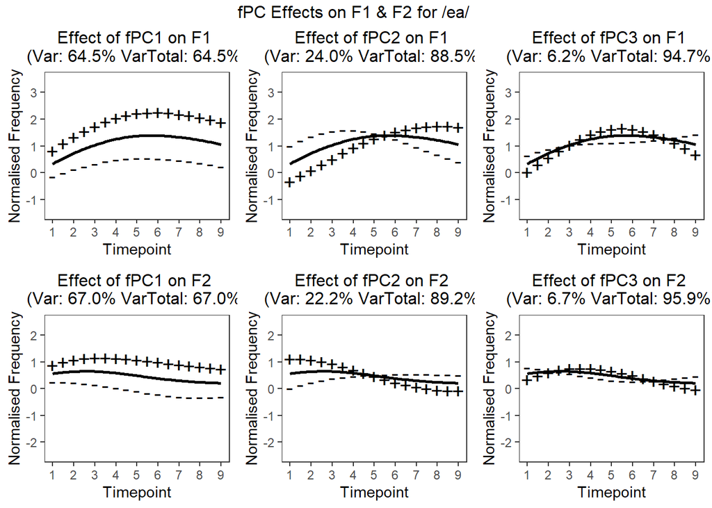

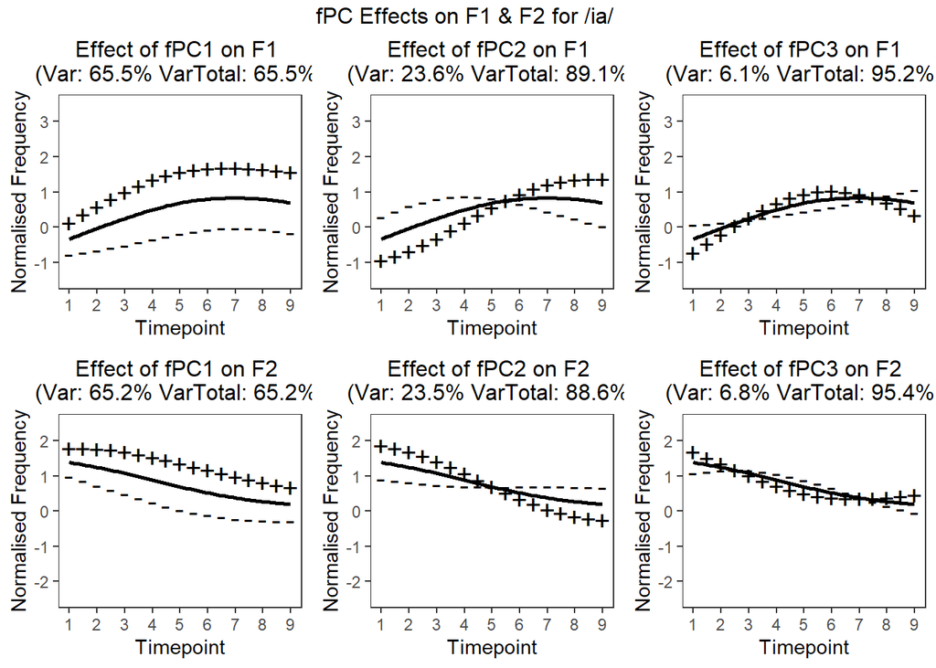

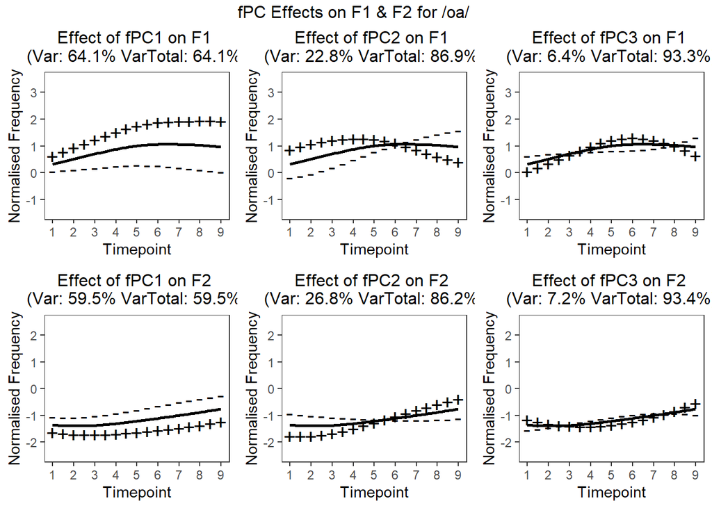

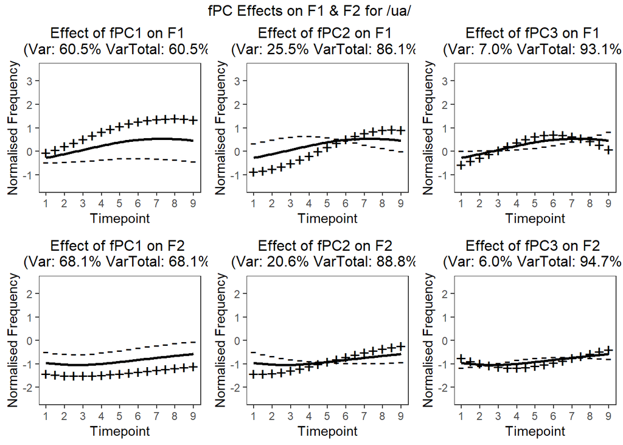

```r
sequences = c("ea","ia","oa","ua")
fpca_type = "form"

for (sequence in sequences){
  plot_PC1_f1 = PlotPCs(1,1,sequence,fpca_type)
  plot_PC1_f2 = PlotPCs(1,2,sequence,fpca_type)
  plot_PC2_f1 = PlotPCs(2,1,sequence,fpca_type)
  plot_PC2_f2 = PlotPCs(2,2,sequence,fpca_type)
  plot_PC3_f1 = PlotPCs(3,1,sequence,fpca_type)
  plot_PC3_f2 = PlotPCs(3,2,sequence,fpca_type)

  big_plot_title = sprintf("fPC Effects on F1 & F2 for /%s/ ",sequence)
  PC_plot_big = grid.arrange(plot_PC1_f1,plot_PC2_f1,plot_PC3_f1,
                             plot_PC1_f2,plot_PC2_f2,plot_PC3_f2,
                             ncol=3,top = textGrob(big_plot_title))
  ggsave(here("Figures", "Plots", "fPCA", paste0("hd_forms_", sequence, ".png")),
         PC_plot_big,scale=1,width=3600,height=2700,units="px")

}
```

**Click here to view code.**

```r
# Clear variables for tidiness
rm(plot_PC1_f1,plot_PC2_f1,plot_PC3_f1,
   plot_PC1_f2,plot_PC2_f2,plot_PC3_f2,
   big_plot_title,PC_plot_big)
```

For each sequence and formant, more than 90% of variance observed was explained by at least three fPCs. As a result, three fPCs have been selected for F1 and F2.

For F1 and F2, fPC1 explains the height and general shape of the mean curve. For F1, fPC2 appears to explain the position of the peak. A high score corresponds to a peak later in the sequence and a low score corresponds to a peak earlier in the sequence. For /oa , the inverse is true: a high score corresponds to a peak earlier in the sequence and a low score corresponds to a peak later in the sequence.

F2, fPC2 seems to captures how extreme the difference is between the onset and offset of the sequence. Finally, fPC3 for both F1 and F2 concerns the transition part of the sequence, in particular whether this has more of a concave or convex shape. For F1, a high fPC3 score reflects a more convex shape, with a central peak, while a low fPC3 score reflects a subtle concave dip in the middle of the sequence. For F2, high fPC3 scores correspond to a subtle concave dip in the middle of the sequence, while low scores correspond to a subtle peak. The inverse is the case for /ea/, where low fPC3 scores correspond to a subtle concave dip and high scores correspond to a subtle peak.

3. Create fPCA plots for pitch and intensity

**Click here to view code.**

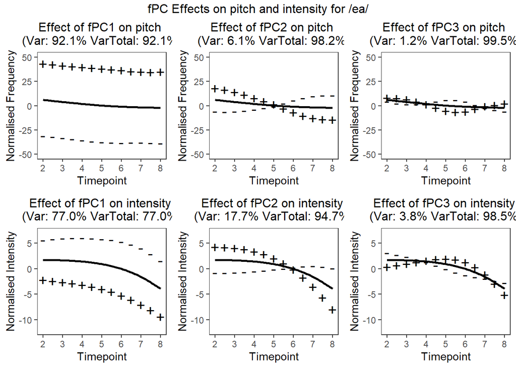

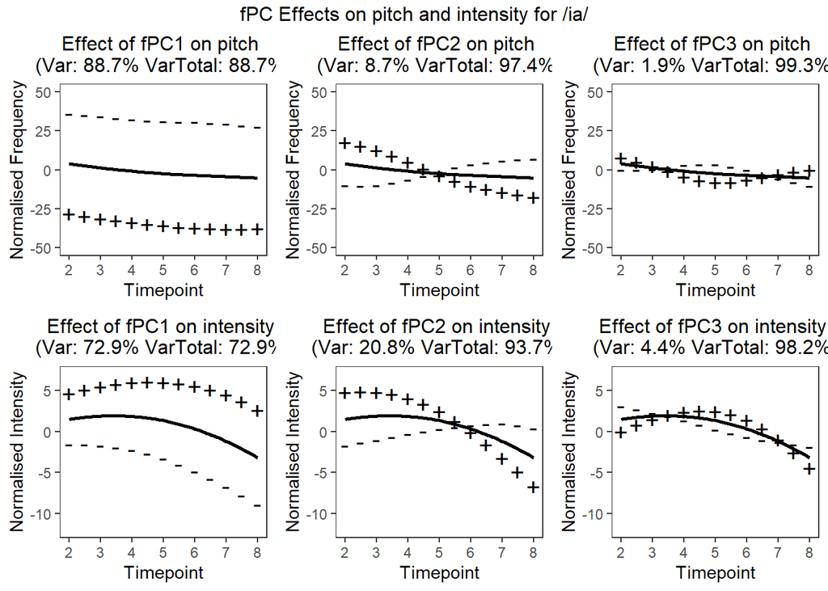

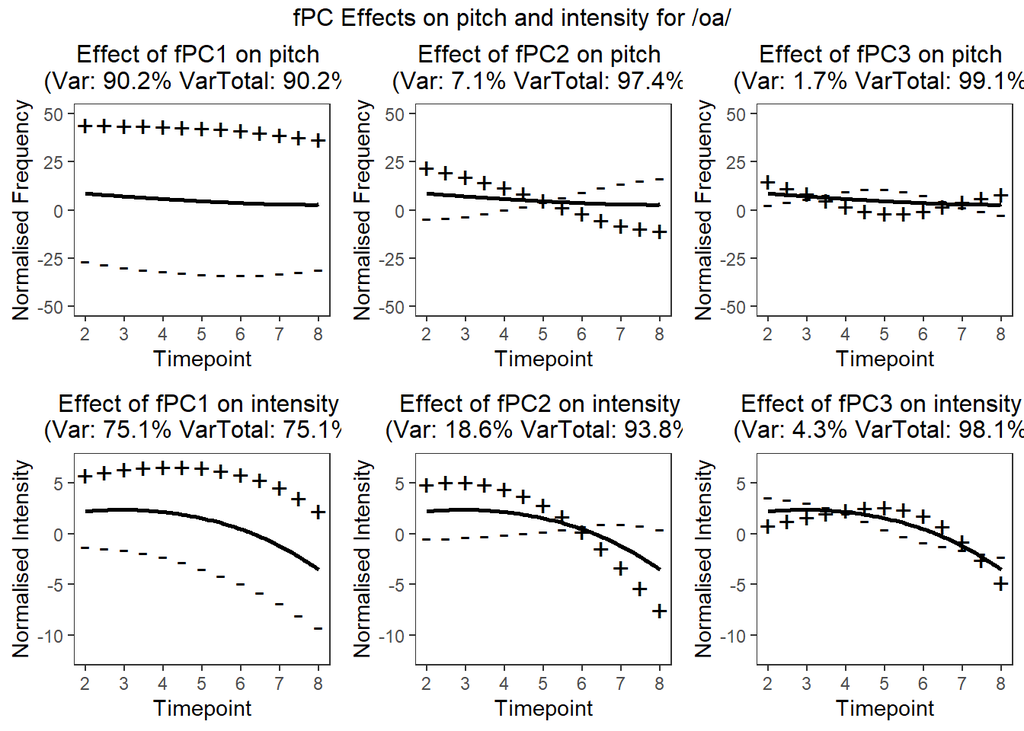

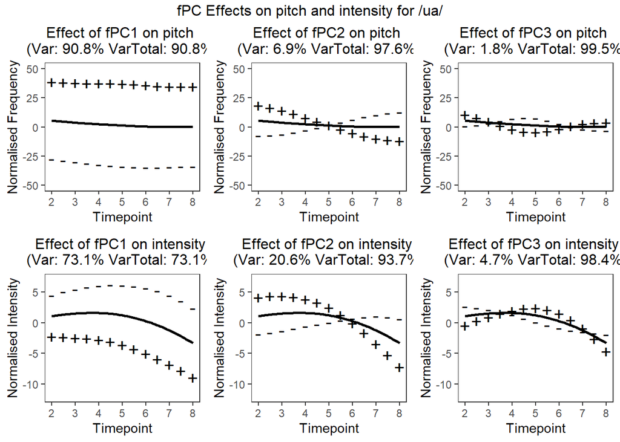

```r
sequences = c("ea","ia","oa","ua")
fpca_type = "pitch"

for (sequence in sequences){
  plot_PC1_pit = PlotPCs(1,1,sequence,fpca_type)
  plot_PC1_int = PlotPCs(1,2,sequence,fpca_type)
  plot_PC2_pit = PlotPCs(2,1,sequence,fpca_type)
  plot_PC2_int = PlotPCs(2,2,sequence,fpca_type)
  plot_PC3_pit = PlotPCs(3,1,sequence,fpca_type)
  plot_PC3_int = PlotPCs(3,2,sequence,fpca_type)

  big_plot_title = sprintf("fPC Effects on pitch and intensity for /%s/",sequence)
  PC_plot_big = grid.arrange(plot_PC1_pit,plot_PC2_pit,plot_PC3_pit,
                             plot_PC1_int,plot_PC2_int,plot_PC3_int,
                             ncol=3,top = textGrob(big_plot_title))
 ggsave(here( "Figures", "Plots", "fPCA", paste0("hd_pit-int_", sequence, ".png")),
       PC_plot_big, scale=1, width=3600, height=2700, units="px")
}
```

**Click here to view code.**

```r
## Clear variables for tidiness
rm(plot_PC1_pit,plot_PC2_pit,plot_PC3_pit,
   plot_PC1_int,plot_PC2_int,plot_PC3_int,
   big_plot_title,PC_plot_big)
```

For pitch and intensity at least 90% of the cumulative variance is explained by two fPCs.  
However, to align with the number of fPCs selected for F1 and F2, and to ensure the threshold is exceeded in every instance, three fPCs were also chosen for pitch and intensity.

## 6.2 Individual fPC plots for Appendix A

This is a slightly adapted version of the function which includes the sequence name in the title of the plots

**Click here to view code.**

```r
## MAIN FUNCTION: Generate a plot given a PC and formant (as integer ID)
PlotPCs_caption = function(PC,fpca_type,sequence,fpca_name,flip_symbols=0){

  ## Create a working dataset
  working_fpca = get(paste(fpca_name,"_fpca_",sequence,sep=""))[[fpca_type]]

  ## get variables from FPCA output
  mean_curve = working_fpca$mu
  PC_curve = working_fpca$phi[,PC]
  PC_mod = PC_curve * sd(working_fpca$xiEst[,PC])
  cum_var = working_fpca$cumFVE

  if (fpca_name == "form"){
    time_start = 1
    time_end = 9
  } else {
    time_start = 2
    time_end = 8
  }

  ## send to "MorePoints" function, get finer detail curves
  mean_curve = MorePoints(mean_curve,time_start,time_end)
  PC_curve = MorePoints(PC_curve,time_start,time_end)
  PC_mod = MorePoints(PC_mod,time_start,time_end)

  FPCA_extract = data.frame(mean_curve,PC_curve,PC_mod)

  # get values for plot title and generate titles
  plot_cum_var = cum_var[PC]*100
  plot_PC_var = UnTotal(cum_var,PC)*100

  if (fpca_name == "form"){
    if (fpca_type == 1){
      plot_effect = "F1"
    } else {
      plot_effect = "F2"
    }
  } else {
    if (fpca_type == 1){
      plot_effect = "pitch"
    } else {
      plot_effect = "intensity"
    }
  }

  plot_title = sprintf("Effect of fPC%s on %s for /%s/ \n(Var: %.1f%% VarTotal: %.1f%%)",PC,plot_effect, sequence, plot_PC_var,plot_cum_var)

  if (fpca_name == "form"){
    # if formant, check which formant and adjust limits accordingly
    if (fpca_type == 1){
      y_min = -1.5
      y_max = 3.5
    } else {
      y_min = -2.5
      y_max = 2.5
    }

  } else {
    # alternatively, if pitch/intensity...
    if (fpca_type == 1){
      y_min = -50
      y_max = 50
    } else {
      y_min = -12
      y_max = 7
    }
  }

  ## change y label to intensity if intensity is being examined
  if (fpca_name == "pitch" & fpca_type == 2){
    ylabel = "Normalised Intensity"
  } else {
    ylabel = "Normalised Frequency"
  }


  ## If "flip_symbols" parameter argument isn't false, flip plus and minus symbols
  if (flip_symbols == 0){
    add_symbol = "+"
    sub_symbol = "-"
  } else {
    add_symbol = "-"
    sub_symbol = "+"
  }

  PC_plot = ggplot(FPCA_extract, aes(x = seq(time_start,time_end,by=0.5))) +

    # plot curves
    geom_smooth(aes(y=mean_curve),se=FALSE,color="black") +
    geom_point(aes(y=mean_curve + PC_mod),
               shape=add_symbol,size=5) +
    geom_point(aes(y=mean_curve - PC_mod),
               shape=sub_symbol,size=5) +

    # format plot
    labs(x="Timepoint",y=ylabel,
         title=plot_title) +
    scale_x_continuous(breaks=seq(time_start,time_end,by=1)) +
    theme_bw() + ylim(y_min,y_max) +
    theme(panel.grid = element_blank(),
          plot.title = element_text(hjust=0.5,size=12))

  return(PC_plot)
}

## SUPPORT FUNCTION: Given a specific curve, predict a finer-detail curve

MorePoints = function(curve,time_start,time_end){
  times=time_start:time_end
  temp_smooth = loess(curve~times)
  temp_smoother = predict(temp_smooth,seq(time_start,time_end,by=0.5))
  return(temp_smoother)
}

## SUPPORT FUNCTION: Return non-cumulative variance contribution
# ('fdapace.FPCA()' objects contain cumulative variances, not individual PC variance)

UnTotal = function(vec,index){
  if (index == 1){
    return(vec[index])
  } else {
    new_vec = vec[index] - vec[index - 1]
    return(new_vec)
  }
}
```

### 6.2.1 Intensity fPC2 (Manuscript Figure A1)

**Click here to view code.**

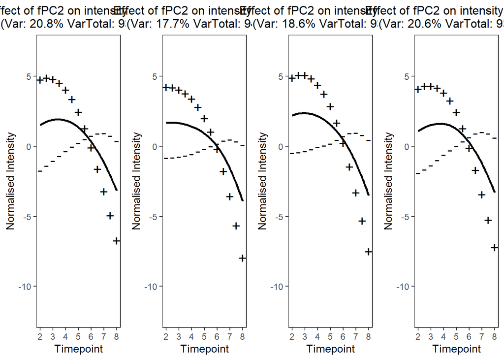

```r
arrange_ia_pc2.int = PlotPCs_caption(2,2,"ia","pitch")
arrange_ea_pc2.int = PlotPCs_caption(2,2,"ea","pitch")
arrange_oa_pc2.int = PlotPCs_caption(2,2,"oa","pitch")
arrange_ua_pc2.int = PlotPCs_caption(2,2,"ua","pitch")


IntPC2All <- grid.arrange(arrange_ia_pc2.int,arrange_ea_pc2.int, arrange_oa_pc2.int, arrange_ua_pc2.int,
             ncol=4)
```

**Click here to view code.**

```r
 ggsave(here( "Figures", "Plots", "fPCA", "IntfPC2All.png") ,IntPC2All, scale=.80,   width=5000,height=1300,units="px")
```

### 6.2.2 F1 fPC1 (Manuscript Figure A2)

**Click here to view code.**

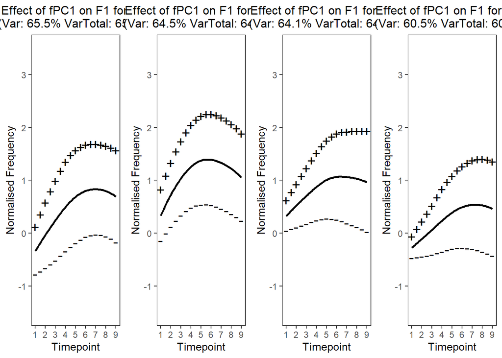

```r
arrange_ia_pc1.f1 = PlotPCs_caption(1,1,"ia","form")
arrange_ea_pc1.f1 = PlotPCs_caption(1,1,"ea","form")
arrange_oa_pc1.f1 = PlotPCs_caption(1,1,"oa","form")
arrange_ua_pc1.f1 = PlotPCs_caption(1,1,"ua","form")




F1PC1All <- grid.arrange(arrange_ia_pc1.f1,arrange_ea_pc1.f1, arrange_oa_pc1.f1, arrange_ua_pc1.f1,
             ncol=4)
```

**Click here to view code.**

```r
 ggsave(here( "Figures", "Plots", "fPCA", "F1fPC1All.png") ,F1PC1All, scale=.80,   width=5000,height=1300,units="px")
```

### 6.2.3 F2 fPC1+ fPC3 /ia/ (Manuscript Figure A3)

**Click here to view code.**

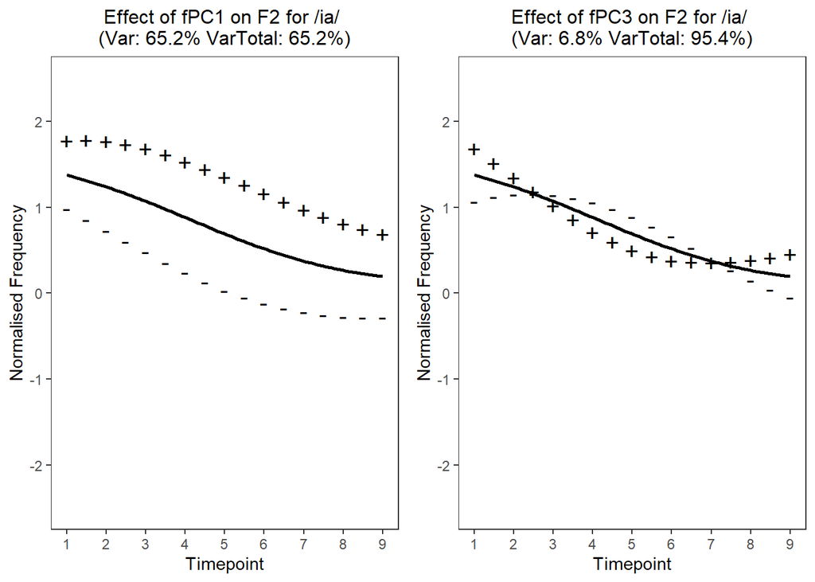

```r
arrange_ia_pc1.f2 = PlotPCs_caption(1,2,"ia","form")
arrange_ia_pc3.f2 = PlotPCs_caption(3,2,"ia","form")


F2ia <- grid.arrange(arrange_ia_pc1.f2, arrange_ia_pc3.f2, ncol=2)
```

**Click here to view code.**

```r
ggsave(here( "Figures", "Plots", "fPCA", "F2ia.png") ,F2ia, scale=.80,   width=2500,height=1300,units="px")
```

# 7 Duration filtering (Manuscript §3.3.3)

Duration filtering occurs at this stage as we only include duration data for sequences which have been through the other filtering processes, and this affects the centering.

1. Read in fPCA data if need be

**Click here to view code.**

```r
fpcadata = read.csv(here("Data", "fpca_merged.csv"))

duration_data = read.csv(here("Data", "opening_seqs_selected_data.csv")) %>%
  unique()
```

2. Filter seqs for inclusion in fPCA

**Click here to view code.**

```r
fpcadata_ids <- fpcadata %>%
  select(sequence, MatchId) %>%
  unique()


duration_data <- left_join(fpcadata_ids, duration_data) %>%
  unique()
```

3. Some data prep

**Click here to view code.**

```r
duration_data <- duration_data %>%
  mutate(Speaker = as.factor(Speaker)) %>%
   mutate(sequence = as.factor(sequence))
```

4. Add duration to data frame, convert to ms

**Click here to view code.**

```r
duration_data$duration = duration_data$Target.vowelCluster.end - duration_data$Target.vowelCluster.start

duration_data <- duration_data %>%
 drop_na(duration) %>%
  mutate(duration_ms = duration * 1000)
```

5. Filter out sequences with duration > 500 ms

**Click here to view code.**

```r
duration_data  <-  duration_data %>%
 filter(duration_ms < 500)

duration_data <- duration_data %>%
mutate(s_duration = scale(duration, center=TRUE, scale=TRUE))

duration_data = duration_data %>% ungroup()
duration_data$s_duration = as.numeric(duration_data$s_duration)
duration = unique(duration_data %>% select(MatchId, s_duration))
```

Note that this threshold was decided on based on manually checking the data. We found that for tokens 500ms +, the proportion of forced alignment errors was 15% or greater. However, we did not manually check the entire data set which contains more than 10,000 tokens. As a result, we do not know exactly how many forced alignment errors remain.

We are now ready to conduct the uPCA!

# 8 uPCA (Manuscript §4.1)

1. Prepare data. Combine duration data with fPCA data, and filter out any NA values for duration.

**Click here to view code.**

```r
uPCA_data = left_join(fpcadata, duration, by="MatchId") %>%
 filter(! is.na(s_duration))
```

2. Rename columns so that they appear more neatly in the index loadings

**Click here to view code.**

```r
uPCA_data <- uPCA_data %>%
  rename(`Duration: z-scored` = s_duration,
         `F1: fPC1` = f1_pc1,
         `F1: fPC2` = f1_pc2,
         `F1: fPC3` = f1_pc3,
         `F2: fPC1` = f2_pc1,
         `F2: fPC2` = f2_pc2,
         `F2: fPC3` = f2_pc3,
         `Pitch: fPC1` = pitch_pc1,
         `Pitch: fPC2` = pitch_pc2,
         `Pitch: fPC3` = pitch_pc3,
         `Intensity: fPC1` = intensity_pc1,
         `Intensity: fPC2` = intensity_pc2,
         `Intensity: fPC3` = intensity_pc3,
  )
```

3. Create seperate data frames, one for each sequence

**Click here to view code.**

```r
ea_data = uPCA_data %>% filter(sequence =="ea")
oa_data = uPCA_data %>% filter(sequence =="oa")
ia_data = uPCA_data %>% filter(sequence =="ia")
ua_data = uPCA_data %>% filter(sequence =="ua")
```

4. Run uPCA for each sequence

**Click here to view code.**

```r
set.seed(1)

oa_test <- pca_test(
  oa_data %>% select(-sequence, -MatchId),
  n = 500,
  variance_confint = 0.95,
  loadings_confint = 0.9
)

ia_test <- pca_test(
  ia_data %>% select(-sequence, -MatchId),
  n = 500,
  variance_confint = 0.95,
  loadings_confint = 0.9
)

ua_test <- pca_test(
  ua_data %>% select(-sequence, -MatchId),
  n = 500,
  variance_confint = 0.95,
  loadings_confint = 0.9
)

ea_test <- pca_test(
  ea_data %>% select(-sequence, -MatchId),
  n = 500,
  variance_confint = 0.95,
  loadings_confint = 0.9
)
```

5. Plot variance explained for each sequence

/ea/

**Click here to view code.**

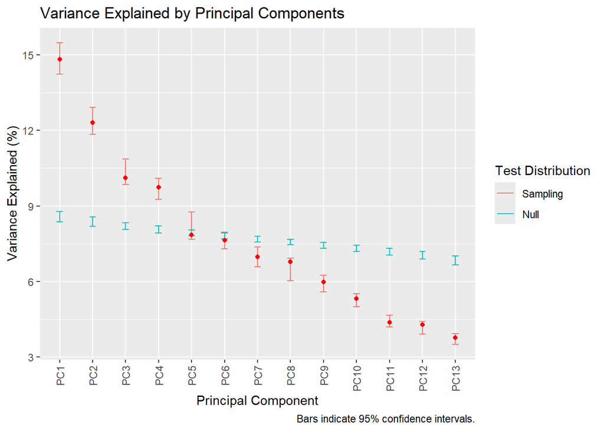

```r
plot_variance_explained(ea_test)
```

/ia/

**Click here to view code.**

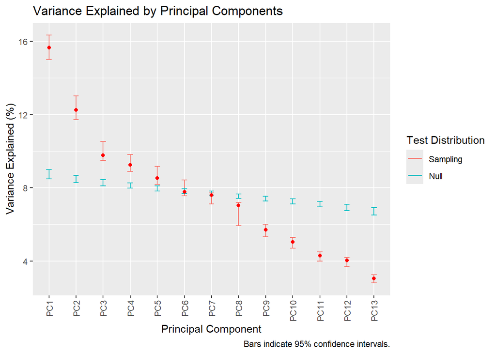

```r
plot_variance_explained(ia_test)
```

/oa/

**Click here to view code.**

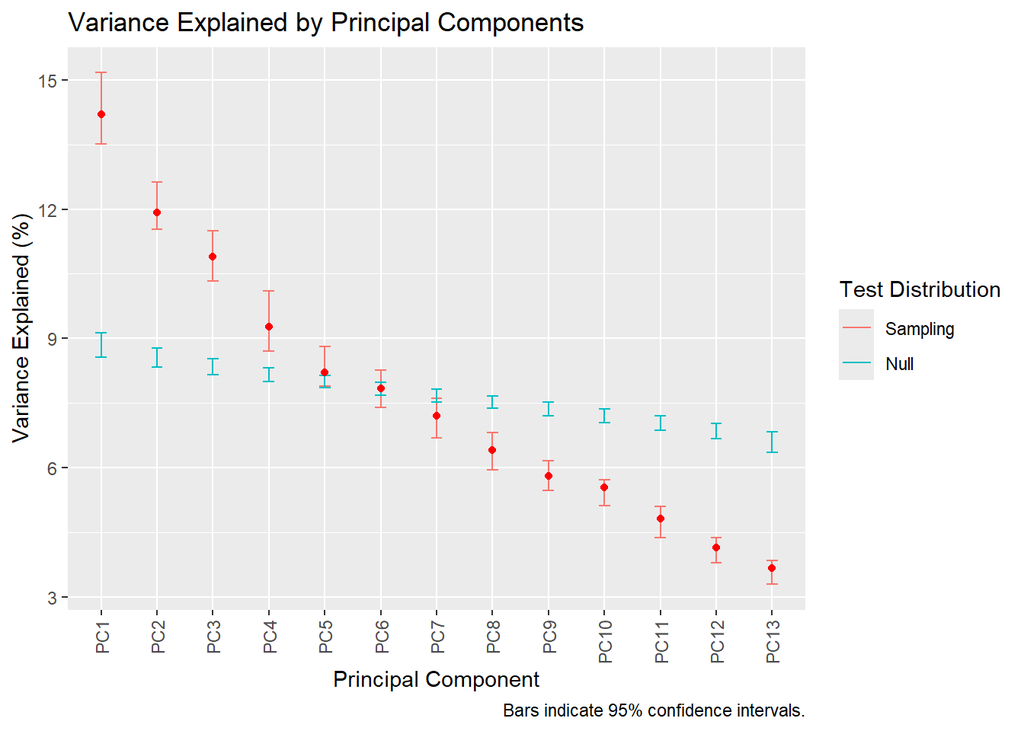

```r
plot_variance_explained(oa_test)
```

/ua/

**Click here to view code.**

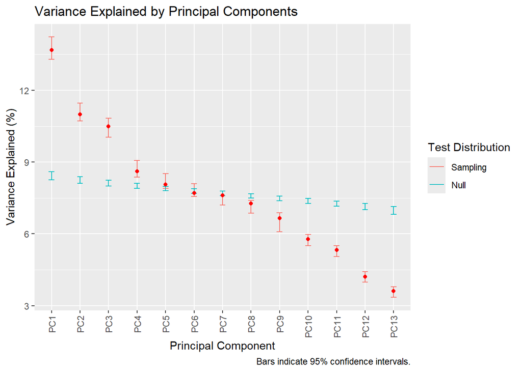

```r
plot_variance_explained(ua_test)
```

## 8.1 Exploring which uPCs to interpret

### 8.1.1 Index loadings for /ea/, uPC1-4

**Click here to view code.**

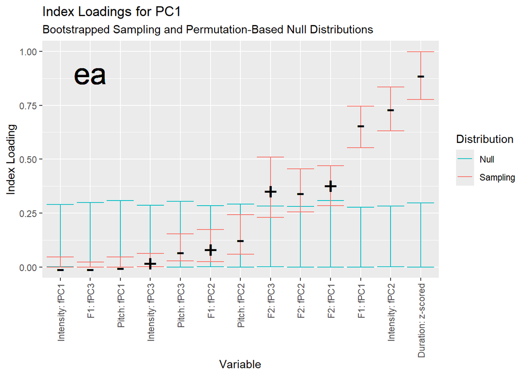

```r
eapc1_loadings_plot_uf <- plot_loadings(ea_test, pc_no=1, filter_boots = FALSE) + geom_text(label="ea",aes(2,.9), size = 10, colour="black")

eapc1_loadings_plot_uf
```

**Click here to view code.**

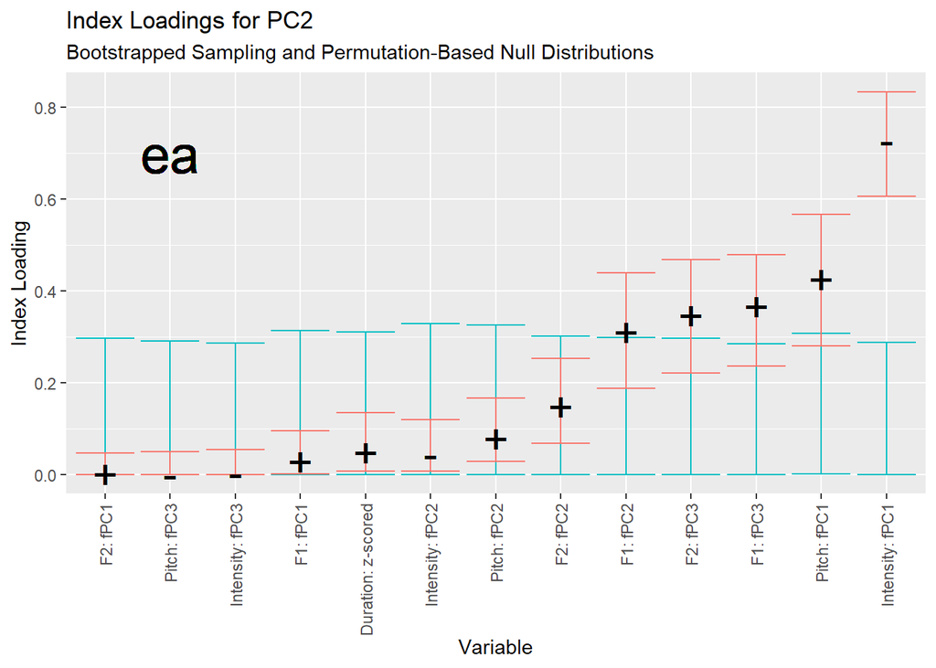

```r
eapc2_loadings_plot_uf <- plot_loadings(ea_test, pc_no=2, filter_boots = FALSE) + geom_text(label="ea",aes(2,.7), size = 10, colour="black") + theme(legend.position = "none")
eapc2_loadings_plot_uf
```

**Click here to view code.**

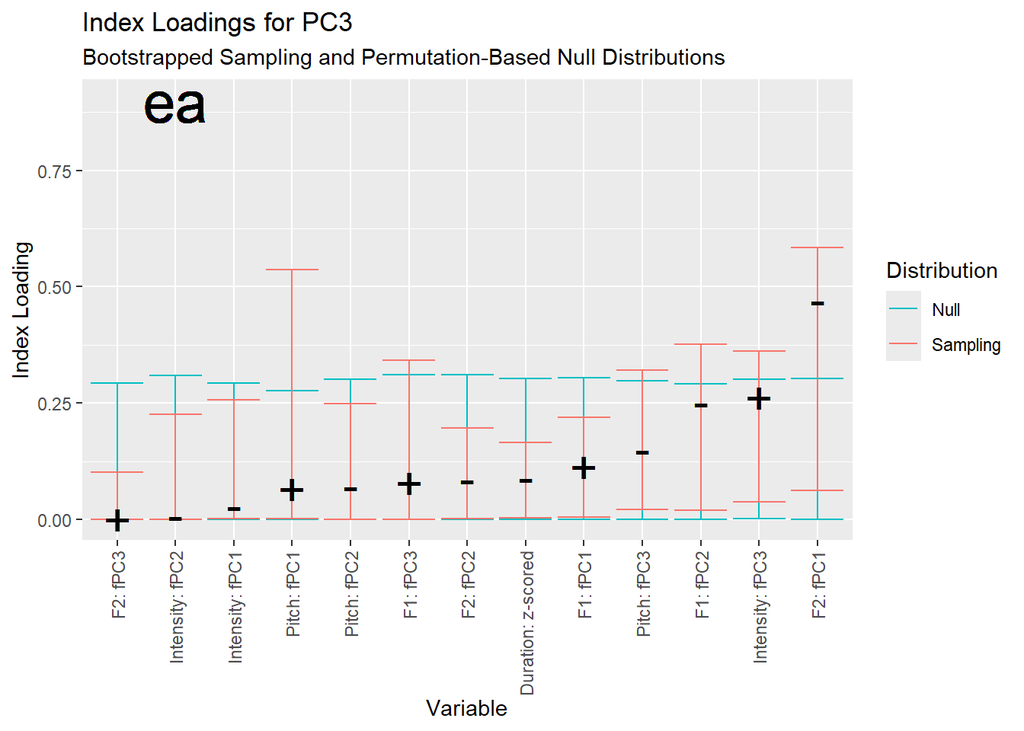

```r
eapc3_loadings_plot_uf <- plot_loadings(ea_test, pc_no=3, filter_boots = FALSE) + geom_text(label="ea",aes(2,.9), size = 10, colour="black")
eapc3_loadings_plot_uf
```

**Click here to view code.**

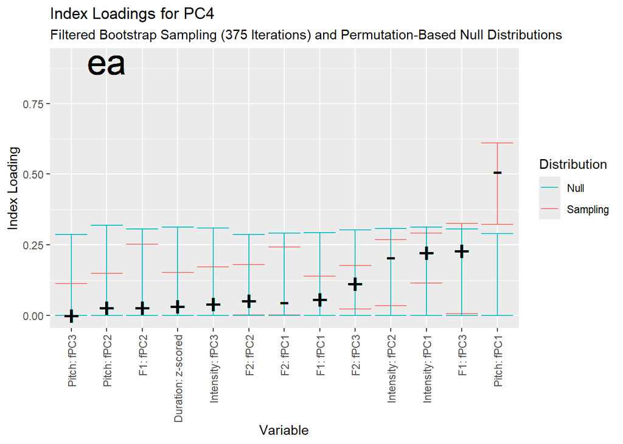

```r
eapc4_loadings_plot_uf <- plot_loadings(ea_test, pc_no=4, filter_boots = TRUE) + geom_text(label="ea",aes(2,.9), size = 10, colour="black")
eapc4_loadings_plot_uf
```

### 8.1.2 Index loadings for /ia/, uPC1-4

**Click here to view code.**

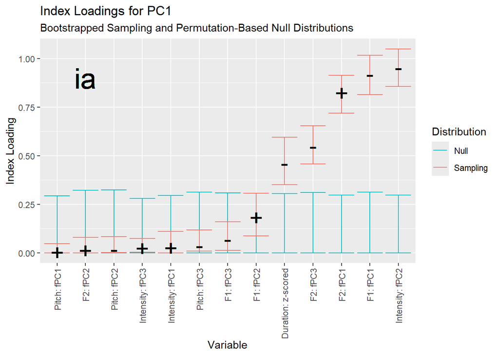

```r
iapc1_loadings_plot_uf <- plot_loadings(ia_test, pc_no=1, filter_boots = FALSE) + geom_text (label="ia",aes(2,.9), size = 10, colour="black")

iapc1_loadings_plot_uf
```

**Click here to view code.**

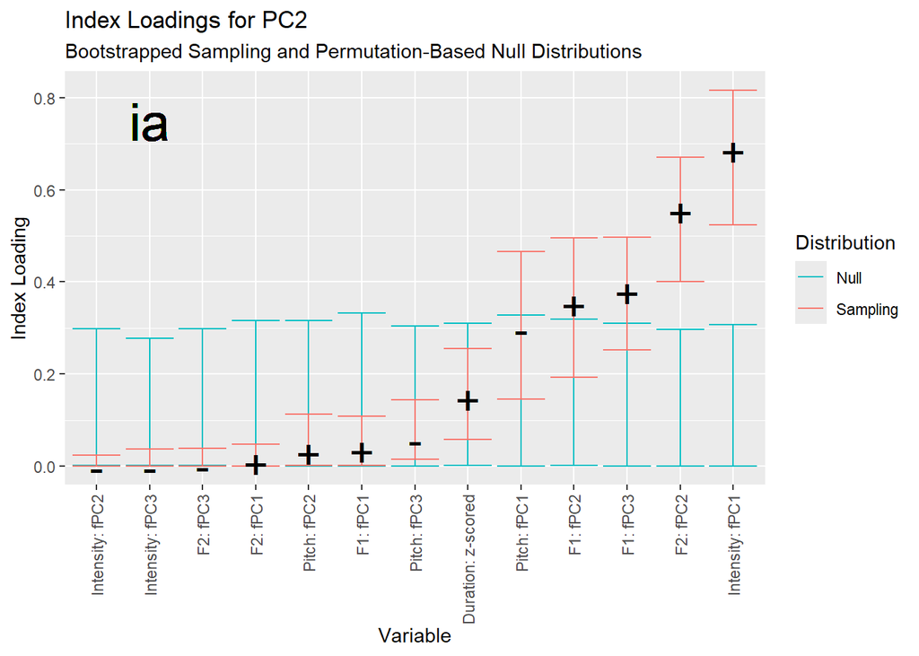

```r
iapc2_loadings_plot_uf <- plot_loadings(ia_test, pc_no=2, filter_boots = FALSE) + geom_text(label="ia",aes(2,.75), size = 10, colour="black")
iapc2_loadings_plot_uf
```

**Click here to view code.**

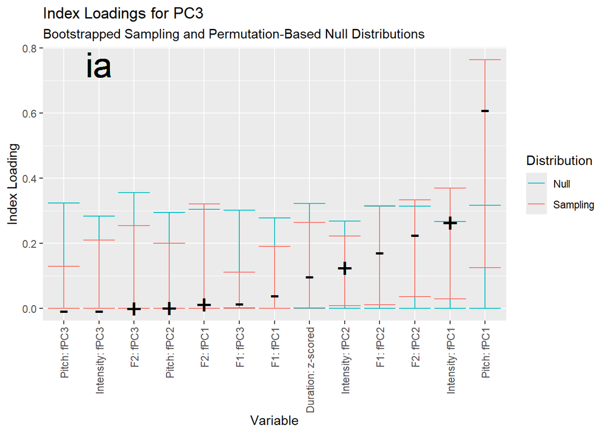

```r
iapc3_loadings_plot_uf <- plot_loadings(ia_test, pc_no=3, filter_boots = FALSE) + geom_text(label="ia",aes(2,.75), size = 10, colour="black")
iapc3_loadings_plot_uf
```

**Click here to view code.**

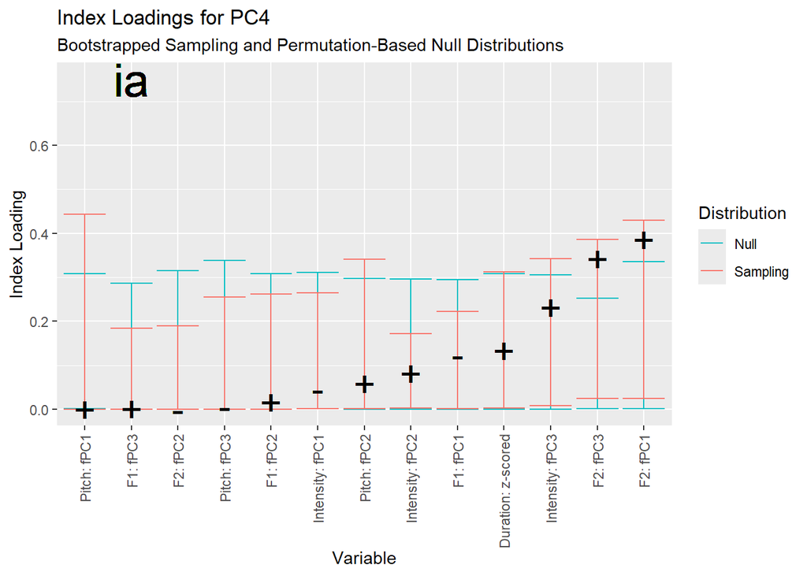

```r
iapc4_loadings_plot_uf <- plot_loadings(ia_test, pc_no=4, filter_boots = FALSE) + geom_text(label="ia",aes(2,.75), size = 10, colour="black")
iapc4_loadings_plot_uf
```

### 8.1.3 Index loadings for /oa/, uPC1-4

**Click here to view code.**

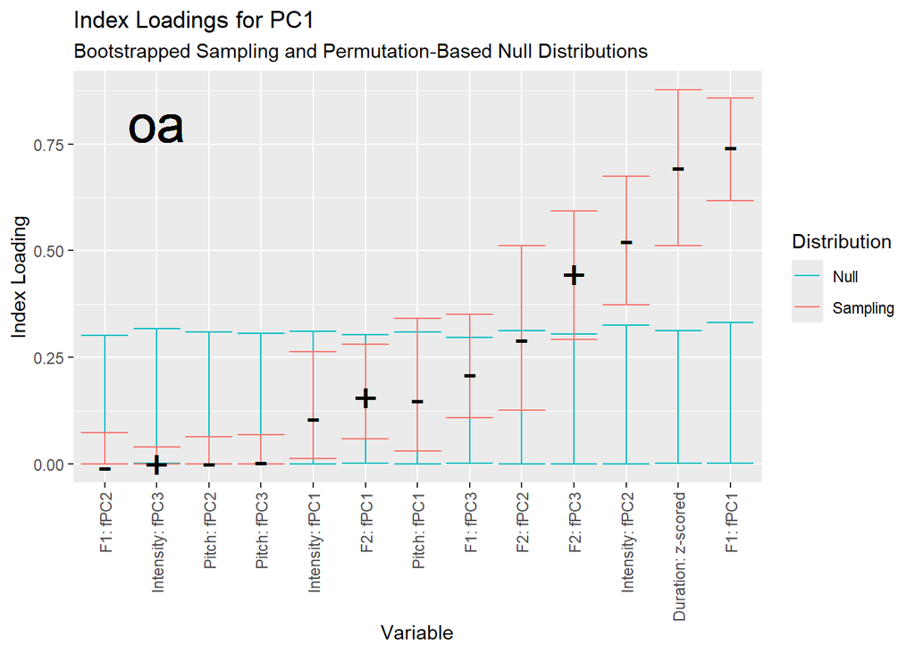

```r
oapc1_loadings_plot_uf <- plot_loadings(oa_test, pc_no=1, filter_boots = FALSE) + geom_text(label="oa",aes(2,.8), size = 10, colour = "black")

oapc1_loadings_plot_uf
```

**Click here to view code.**

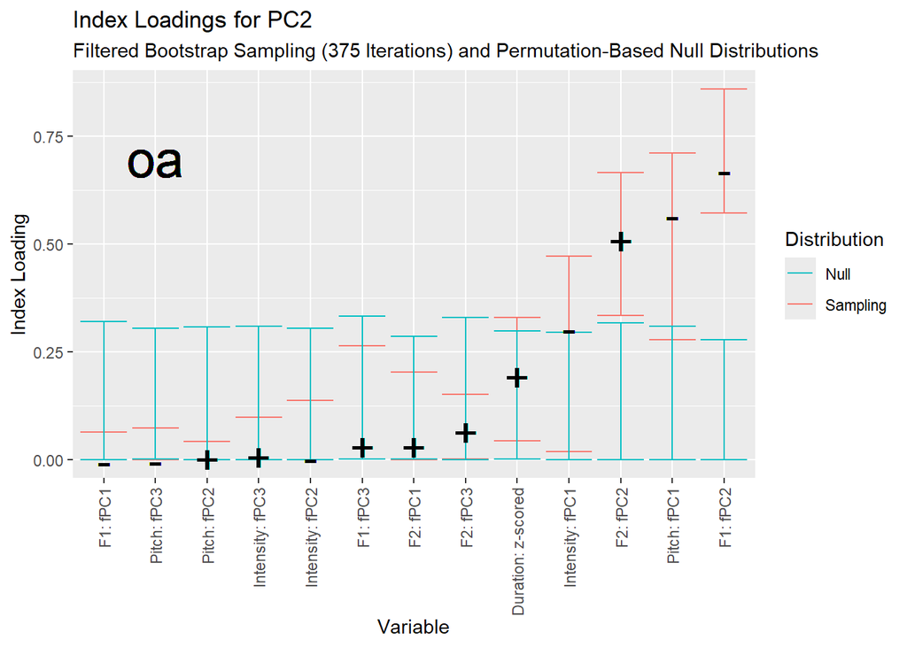

```r
oapc2_loadings_plot_uf <- plot_loadings(oa_test, pc_no=2, filter_boots = TRUE) + geom_text(label="oa",aes(2,.7), size = 10, colour="black")
oapc2_loadings_plot_uf
```

**Click here to view code.**

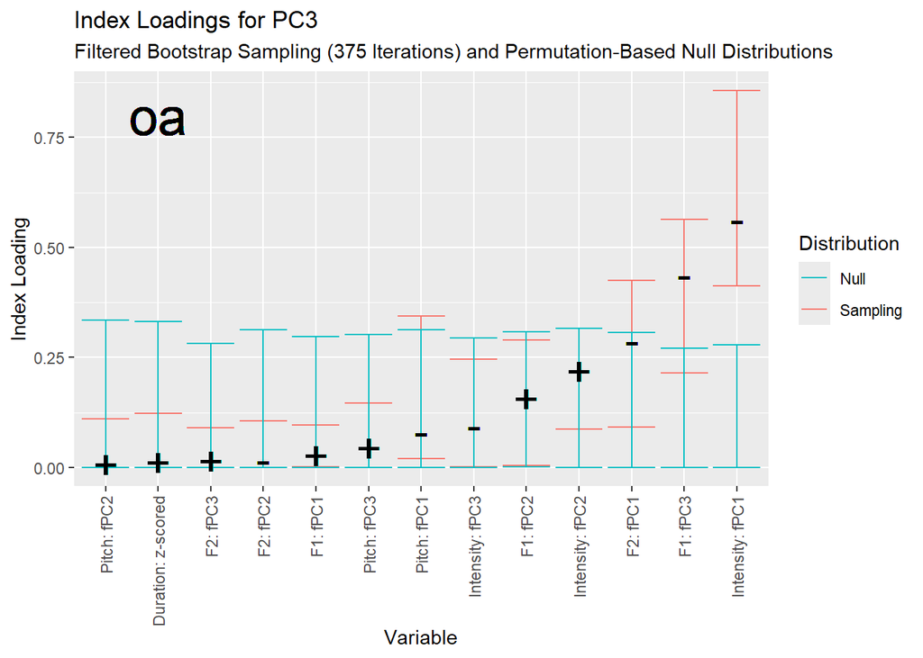

```r
oapc3_loadings_plot_uf <- plot_loadings(oa_test, pc_no=3, filter_boots = TRUE) + geom_text(label="oa",aes(2,.8), size = 10, colour = "black")
oapc3_loadings_plot_uf
```

**Click here to view code.**

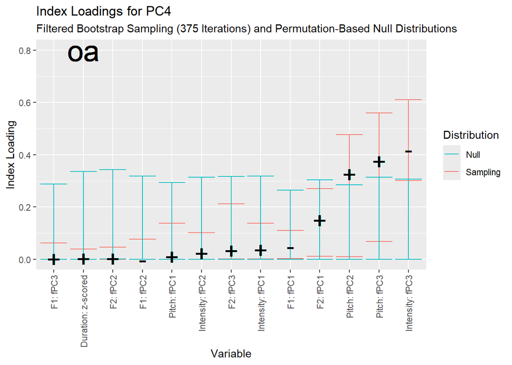

```r
oapc4_loadings_plot_uf <- plot_loadings(oa_test, pc_no=4, filter_boots = TRUE)+ geom_text(label="oa",aes(2,.8), size = 10, colour = "black")
oapc4_loadings_plot_uf
```

### 8.1.4 Index loadings for /ua/, uPC1-4

1. Flip the loadings to match the others.

**Click here to view code.**

```r
ua_test$loadings <- ua_test$loadings %>%
   mutate(
        loading = if_else(PC == "PC1", loading * -1, loading)
    )
```

**Click here to view code.**

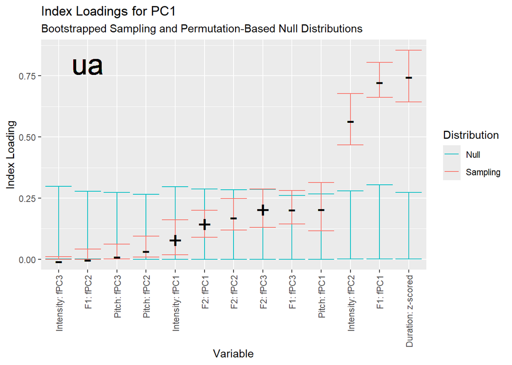

```r
uapc1_loadings_plot_uf <- plot_loadings(ua_test, pc_no=1, filter_boots = FALSE)+ geom_text(label="ua",aes(2,.8), size = 10, colour="black")
uapc1_loadings_plot_uf
```

**Click here to view code.**

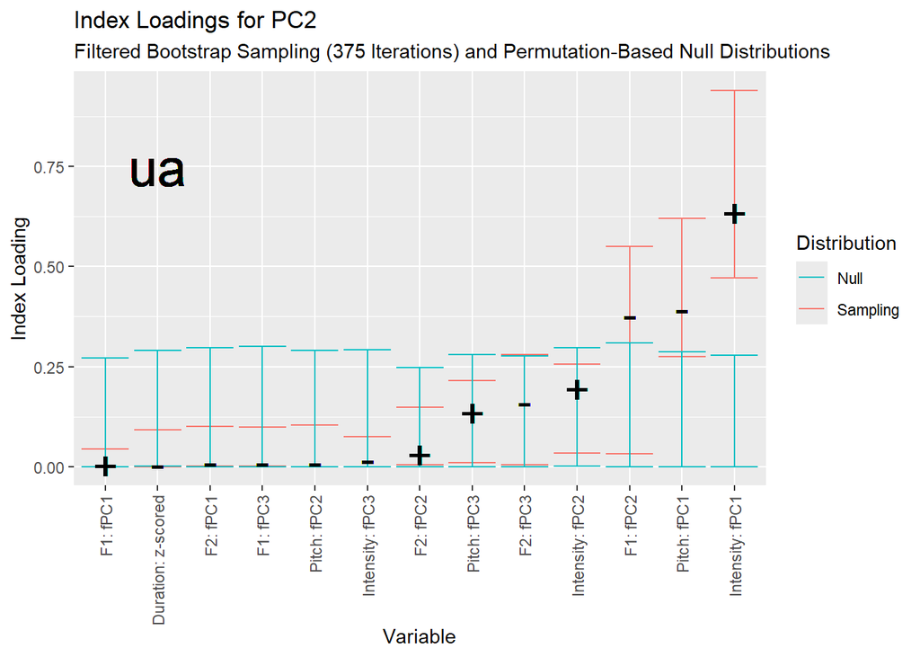

```r
uapc2_loadings_plot_uf <- plot_loadings(ua_test, pc_no=2, filter_boots = TRUE) + geom_text(label="ua",aes(2,.75), size = 10, colour="black")
uapc2_loadings_plot_uf
```

**Click here to view code.**

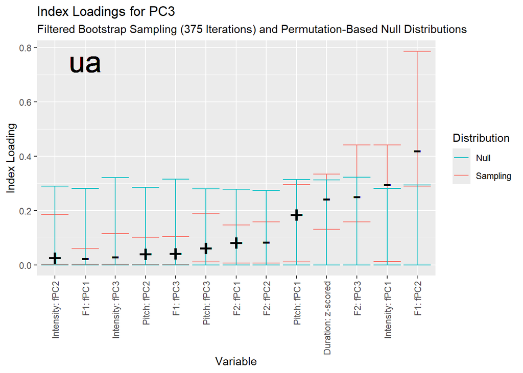

```r
uapc3_loadings_plot_uf <- plot_loadings(ua_test, pc_no=3, filter_boots = TRUE) + geom_text(label="ua",aes(2,.75), size = 10, colour="black")
uapc3_loadings_plot_uf
```

**Click here to view code.**

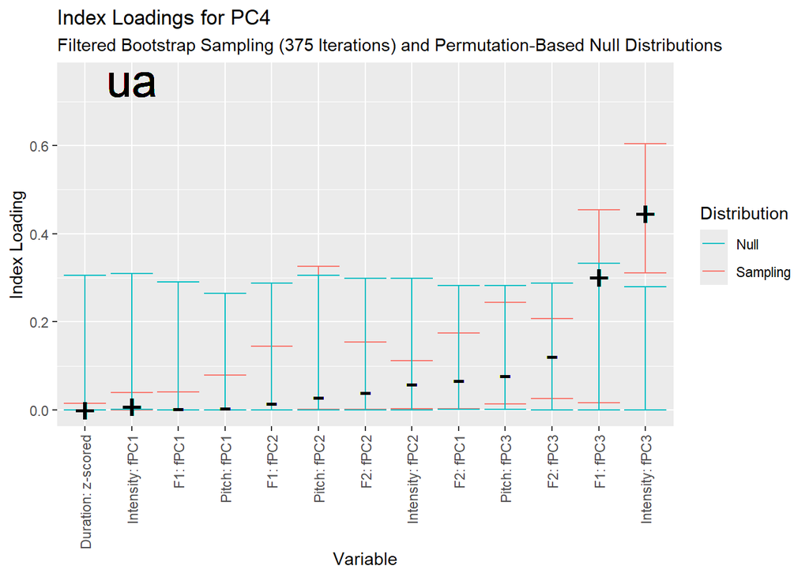

```r
uapc4_loadings_plot_uf <- plot_loadings(ua_test, pc_no=4, filter_boots = TRUE) + geom_text(label="ua",aes(2,.75), size = 10, colour="black")
uapc4_loadings_plot_uf
```

## 8.2 Create horizontal index loading plot for uPC1 (Manuscript Figure 2)

1. Define custom function for creating horizontal index loading plots. This code is adapted from the plot_loadings() function (used above) in the nzilbb.vowels() package (Wilson Black and Brand 2022)

**Click here to view code.**

```r
plot_loadings_horizontal <- function(
    pca_test, pc_no = 1, violin=FALSE, filter_boots = FALSE,
    quantile_threshold = 0.25
) {

  stopifnot(
    "Data must come from an object of class pca_test_results" =
      class(pca_test) == "pca_test_results",
    "pc_no must be a number." =
      is.numeric(pc_no),
    "violin must be either TRUE or FALSE." =
      is.logical(violin),
    "filter_boots must be either TRUE or FALSE." =
      is.logical(filter_boots)
  )

  if (filter_boots) {

    plot_data <- pca_test$raw_data |>
      filter(
        as.numeric(str_sub(.data$PC, start = 3L)) == pc_no,
        source != "original"
      ) |>
      group_by(.data$source, .data$variable) |>
      mutate(
        median_index = stats::median(.data$index_loading),
        quant_threshold = stats::quantile(
          .data$index_loading,
          quantile_threshold
        )
      ) |>
      ungroup() |>
      mutate(
        largest_loading = .data$median_index == base::max(.data$median_index),
      ) |>
      group_by(.data$source, .data$iteration) |>
      filter(
        source != "bootstrapped" |
        any(
          .data$largest_loading & .data$index_loading >= .data$quant_threshold
        )
      ) |>
      group_by(.data$source, .data$variable) |>
      mutate(
        low_limit = stats::quantile(
          .data$index_loading,
          (1 - pca_test$loadings_confint)/2
        ),
        high_limit = stats::quantile(
          .data$index_loading,
          1 - (1 - pca_test$loadings_confint)/2
        )
      ) |>
      ungroup() |>
      mutate(
        distribution = if_else(
          .data$source == "bootstrapped",
          "Sampling",
          "Null"
        )
      ) |>
      select(-.data$index_loading, -.data$loading) |>
      left_join(
        pca_test$loadings |> select(
          .data$PC,
          .data$variable,
          .data$index_loading,
          .data$loading
        ),
        by = c("PC", "variable")
      )

    # Calculate count of kept iterations for subtitle
    kept_iterations <- plot_data |>
      filter(
        .data$distribution == "Sampling"
      ) |>
      pull(.data$iteration) |>
      base::unique() |>
      base::length()

    subtitle = glue(
      "Filtered Bootstrap Sampling ({kept_iterations} Iterations) ",
      "and Permutation-Based Null Distributions"
    )

  } else {

    plot_data <- pca_test$loadings |>
      # Filter so we only have data from desired PC.
      filter(
        as.numeric(str_sub(.data$PC, start = 3L)) == pc_no
      ) |>
      # Reshape so that both permutation and bootstrapped limits are on same
      # variables.
      pivot_longer(
        cols = contains('low'),
        names_to = "distribution",
        values_to = 'low_limit',
        names_pattern = "_(.*)"
      ) |>
      pivot_longer(
        cols = contains('high'),
        names_to = "distribution_2",
        values_to = 'high_limit',
        names_pattern = "_(.*)"
      ) |>
      filter(
        .data$distribution == .data$distribution_2
      ) |>
      select(-"distribution_2") |>
      mutate(
        distribution = if_else(
          str_detect(.data$distribution, 'null'),
          "Null",
          "Sampling"
        )
      )

    subtitle = glue(
      "Bootstrapped Sampling and Permutation-Based Null Distributions"
    )

  }

  plot_data <- plot_data |>
    mutate(
      # Reorder 'variable'  column so variables plotted in ascending order by
      # loading.
      variable = fct_reorder(.data$variable, .data$index_loading),
      loading_sign = if_else(.data$loading < 0, "-", "+")
    )

  if (violin) {

    violin_data <- pca_test$raw_data |>
      filter(
        source == "bootstrapped",
        as.numeric(str_sub(.data$PC, start = 3L)) == pc_no
      ) |>
      mutate(
        distribution = "Sampling"
      ) |>
      select(
        .data$distribution,
        .data$variable,
        .data$index_loading,
        .data$loading,
        .data$iteration
      ) |>
      # Reorder 'variable'  column so variables plotted in ascending order by
      # median bootstrapped loading.
      group_by(.data$variable) |>
      mutate(
        median_index = stats::median(.data$index_loading)
      ) |>
      ungroup() |>
      mutate(
        variable = fct_reorder(.data$variable, .data$median_index)
      )

    if (filter_boots) {
      violin_data <- violin_data |>
        group_by(.data$variable) |>
        mutate(
          first_quartile = stats::quantile(.data$index_loading, 0.25)
        ) |>
        ungroup() |>
        mutate(
          largest_loading = .data$median_index == max(.data$median_index),
        ) |>
        group_by(.data$iteration) |>
        filter(
          any(.data$largest_loading & .data$index_loading >= .data$first_quartile)
        )

      kept_iterations <- base::length(base::unique(violin_data$iteration))

    }

    violin_element <- geom_violin(
        data = violin_data,
        alpha = 0.5
      )

  } else {

    violin_element <- NULL

  }

  out_plot <- plot_data |>
    ggplot(
      aes(
        x = .data$index_loading,
        y = .data$variable,
        colour = .data$distribution
      )
    ) +
    violin_element +
    geom_errorbar(
      aes(
        xmin = .data$low_limit,
        xmax = .data$high_limit
      )
    ) +
    # geom_point(colour = "red") +
    geom_text(aes(label = .data$loading_sign), size = 8, colour = "black", vjust = 0.4, family = "Consolas" ) +
    scale_colour_manual(
      values = c("Sampling" = "#F8766D", "Null" = "#00BFC4")
    ) +
    labs(
      title = glue("Index Loadings for PC{pc_no}"),
      subtitle = subtitle,
      colour = "Distribution",
      y = "Variable",
      x = "Index Loading"
    )

  out_plot

}
```

2. /ia/ uPC1 index loadings

**Click here to view code.**

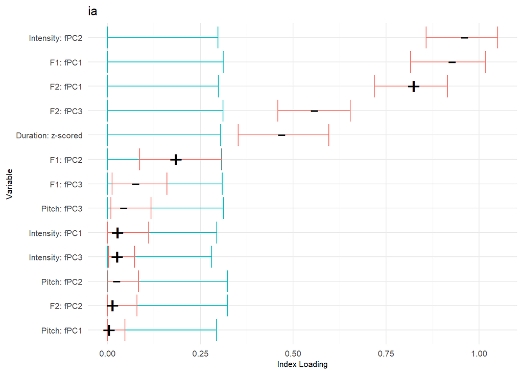

```r
iapc1_loadings_plot_horizonal <- plot_loadings_horizontal(ia_test, pc_no=1, filter_boots = FALSE) +
     theme_minimal() + theme(legend.position = "none", plot.title = element_text(size = 12), text = element_text(size = 8), axis.text = element_text(size = 8))+  labs(title = "ia", subtitle = NULL)
iapc1_loadings_plot_horizonal
```